# Social Network Analysis

Analysis

Federico Bianchi

# 1 Introduction

- This is a notebook for hands-on sessions of the Social Network Analysis graduate course of the University of Milan.
- Analysed data are taken from

Bianchi, F., Casnici, N., & Squazzoni, F. (2018). Solidarity as a byproduct of professional collaboration. Social support and trust in a coworking space. *Social Networks*, 54: 61-72. doi: https://doi.org/10.1016/j.socnet.2017.12.002.

# 2 Packages

It is good practice to upload the needed packages at the beginning of your notebook.

```r
library(tidyverse)
library(here)
library(igraph)
library(ggraph)
library(tidygraph)
library(magrittr)
library(egor)
library(statnet)
```

# 3 Loading data

## 3.1 Collaboration

- Now, we need to import data on *collaboration* relationships.
- In order to let `R` find the data, we need to move the data file to the same directory where our Rstudio project is located (i.e., the *working directory*)

If you don’t remember what working directory you’re in:

```r
getwd()
```

```
## [1] "/Users/federico/Desktop/sna-class-24"
```

- Let’s inspect the data structure: we could either open the file outside Rstudio or even from within
- It’s a .txt file.
- It’s an **adjacency matrix** (see slides)
- Values are 0 and 1 and are separated by a tab (`\t`)
- In order to load it, we need a function to read a table data structure.
- `read.table` is classic R, while `readr::read_delim` is faster. It’s included in the `tidyverse`, which we have already uploaded.

Now we can inspect the `read_delim` function in the console, by hitting

```r
?read_delim
```

What information do we need?

- the file name: `collaboration.txt`
- the column separator: `"\t"`
- whether we have column names: no

Where is my data file?

```r
dir()
```

```
## [1] "data"                  "sna-class-24.Rproj"    "sna-notebook_files"
## [4] "sna-notebook.html"     "sna-notebook.nb.html"  "sna-notebook.Rmd"
## [7] "wp-sna-notebook_files" "wp-sna-notebook.Rmd"
```

In order to maximise reproducibility, we need the path to be available to all possible colleagues. We can use the `here::here` function, which builds a new path regardless of the original path. More here.

Let’s load the collaboration data

The function `here()` finds my working directory and builds a plausible path towards the specified arguments.

```r
here("data", "collaboration.txt")
```

```
## [1] "/Users/federico/Desktop/sna-class-24/data/collaboration.txt"
```

Now we’re ready to load collaboration data as a new object. We can use `read_tsv`, which takes `"\t"` as a default value of the `delim` parameter

```r
read_tsv(
  file = here("data", "collaboration.txt"),
  col_names = FALSE
)
```

| X1 | X2 | X3 | X4 | X5 | X6 | X7 | X8 | X9 | X10 | X11 | X12 | X13 | X14 | X15 | X16 | X17 | X18 | X19 | X20 | X21 | X22 | X23 | X24 | X25 | X26 | X27 | X28 | X29 |
| --- | --- | --- | --- | --- | --- | --- | --- | --- | --- | --- | --- | --- | --- | --- | --- | --- | --- | --- | --- | --- | --- | --- | --- | --- | --- | --- | --- | --- |
| 0 | 0 | 0 | 0 | 0 | 0 | 0 | 0 | 0 | 0 | 0 | 1 | 0 | 0 | 0 | 0 | 0 | 0 | 0 | 0 | 0 | 0 | 0 | 0 | 0 | 0 | 0 | 0 | 0 |
| 0 | 0 | 0 | 1 | 0 | 0 | 1 | 1 | 1 | 1 | 0 | 0 | 1 | 1 | 1 | 1 | 0 | 0 | 0 | 0 | 0 | 0 | 0 | 0 | 0 | 0 | 0 | 0 | 0 |
| 0 | 0 | 0 | 0 | 0 | 1 | 0 | 1 | 1 | 1 | 0 | 0 | 0 | 1 | 0 | 0 | 0 | 0 | 1 | 1 | 0 | 0 | 1 | 0 | 1 | 1 | 1 | 1 | 0 |
| 0 | 1 | 0 | 0 | 0 | 0 | 0 | 0 | 1 | 1 | 0 | 0 | 0 | 1 | 0 | 0 | 0 | 0 | 0 | 0 | 0 | 0 | 0 | 0 | 0 | 0 | 0 | 0 | 0 |
| 0 | 0 | 0 | 0 | 0 | 0 | 0 | 0 | 0 | 0 | 0 | 0 | 0 | 0 | 0 | 0 | 0 | 0 | 0 | 0 | 0 | 0 | 0 | 0 | 0 | 0 | 0 | 0 | 0 |
| 0 | 0 | 1 | 0 | 0 | 0 | 0 | 0 | 1 | 1 | 0 | 0 | 1 | 0 | 1 | 1 | 1 | 0 | 1 | 1 | 0 | 0 | 1 | 0 | 0 | 0 | 0 | 0 | 0 |
| 0 | 1 | 0 | 0 | 0 | 0 | 0 | 0 | 0 | 0 | 0 | 0 | 0 | 0 | 0 | 0 | 0 | 0 | 0 | 0 | 1 | 0 | 0 | 0 | 0 | 0 | 0 | 0 | 0 |
| 0 | 1 | 1 | 0 | 0 | 0 | 0 | 0 | 0 | 1 | 0 | 0 | 0 | 0 | 0 | 0 | 0 | 0 | 1 | 0 | 1 | 0 | 0 | 0 | 0 | 0 | 1 | 1 | 0 |
| 0 | 1 | 1 | 1 | 0 | 1 | 0 | 0 | 0 | 0 | 0 | 0 | 0 | 1 | 0 | 0 | 0 | 0 | 1 | 1 | 0 | 0 | 1 | 0 | 0 | 0 | 0 | 0 | 0 |
| 0 | 1 | 1 | 1 | 0 | 1 | 0 | 1 | 0 | 0 | 0 | 0 | 1 | 0 | 1 | 1 | 0 | 0 | 1 | 1 | 1 | 0 | 1 | 0 | 0 | 1 | 1 | 1 | 0 |

[output cut: 19 more lines]

What kind of object have we stored our data in?

```r
here("data", "collaboration.txt") %>%
  read_tsv(col_names = FALSE) %>%
  class()
```

```
## [1] "spec_tbl_df" "tbl_df"      "tbl"         "data.frame"
```

It’s a `tibble`, the `tidyverse` version of a `data.frame`.

Let’s inspect our data

```r
here("data", "collaboration.txt") %>%
  read_tsv(col_names = FALSE) %>%
  str()
```

```
## spc_tbl_ [29 × 29] (S3: spec_tbl_df/tbl_df/tbl/data.frame)
##  $ X1 : num [1:29] 0 0 0 0 0 0 0 0 0 0 ...
##  $ X2 : num [1:29] 0 0 0 1 0 0 1 1 1 1 ...
##  $ X3 : num [1:29] 0 0 0 0 0 1 0 1 1 1 ...
##  $ X4 : num [1:29] 0 1 0 0 0 0 0 0 1 1 ...
##  $ X5 : num [1:29] 0 0 0 0 0 0 0 0 0 0 ...
##  $ X6 : num [1:29] 0 0 1 0 0 0 0 0 1 1 ...
##  $ X7 : num [1:29] 0 1 0 0 0 0 0 0 0 0 ...
##  $ X8 : num [1:29] 0 1 1 0 0 0 0 0 0 1 ...
##  $ X9 : num [1:29] 0 1 1 1 0 1 0 0 0 0 ...
##  $ X10: num [1:29] 0 1 1 1 0 1 0 1 0 0 ...
##  $ X11: num [1:29] 0 0 0 0 0 0 0 0 0 0 ...
##  $ X12: num [1:29] 1 0 0 0 0 0 0 0 0 0 ...
##  $ X13: num [1:29] 0 1 0 0 0 1 0 0 0 1 ...
##  $ X14: num [1:29] 0 1 1 1 0 0 0 0 1 0 ...
##  $ X15: num [1:29] 0 1 0 0 0 1 0 0 0 1 ...
##  $ X16: num [1:29] 0 1 0 0 0 1 0 0 0 1 ...
##  $ X17: num [1:29] 0 0 0 0 0 1 0 0 0 0 ...
##  $ X18: num [1:29] 0 0 0 0 0 0 0 0 0 0 ...
##  $ X19: num [1:29] 0 0 1 0 0 1 0 1 1 1 ...
##  $ X20: num [1:29] 0 0 1 0 0 1 0 0 1 1 ...
##  $ X21: num [1:29] 0 0 0 0 0 0 1 1 0 1 ...
##  $ X22: num [1:29] 0 0 0 0 0 0 0 0 0 0 ...
##  $ X23: num [1:29] 0 0 1 0 0 1 0 0 1 1 ...
##  $ X24: num [1:29] 0 0 0 0 0 0 0 0 0 0 ...
##  $ X25: num [1:29] 0 0 1 0 0 0 0 0 0 0 ...
##  $ X26: num [1:29] 0 0 1 0 0 0 0 0 0 1 ...
##  $ X27: num [1:29] 0 0 1 0 0 0 0 1 0 1 ...
##  $ X28: num [1:29] 0 0 1 0 0 0 0 1 0 1 ...
##  $ X29: num [1:29] 0 0 0 0 0 0 0 0 0 0 ...
##  - attr(*, "spec")=
##   .. cols(
##   ..   X1 = col_double(),
##   ..   X2 = col_double(),
##   ..   X3 = col_double(),
##   ..   X4 = col_double(),
##   ..   X5 = col_double(),
##   ..   X6 = col_double(),
##   ..   X7 = col_double(),
##   ..   X8 = col_double(),
```

[output cut: 8 more lines]

```
##   ..   X17 = col_double(),
##   ..   X18 = col_double(),
##   ..   X19 = col_double(),
##   ..   X20 = col_double(),
##   ..   X21 = col_double(),
##   ..   X22 = col_double(),
##   ..   X23 = col_double(),
##   ..   X24 = col_double(),
##   ..   X25 = col_double(),
##   ..   X26 = col_double(),
##   ..   X27 = col_double(),
##   ..   X28 = col_double(),
##   ..   X29 = col_double()
##   .. )
##  - attr(*, "problems")=<externalptr>
```

- It’s interpreted as a case-by-variable matrix, with 29 variables.
- Instead, what we need is an adjacency matrix.

```r
here("data", "collaboration.txt") %>%
  read_tsv(col_names = FALSE) %>%
  as.matrix()
```

```
##       X1 X2 X3 X4 X5 X6 X7 X8 X9 X10 X11 X12 X13 X14 X15 X16 X17 X18 X19 X20
##  [1,]  0  0  0  0  0  0  0  0  0   0   0   1   0   0   0   0   0   0   0   0
##  [2,]  0  0  0  1  0  0  1  1  1   1   0   0   1   1   1   1   0   0   0   0
##  [3,]  0  0  0  0  0  1  0  1  1   1   0   0   0   1   0   0   0   0   1   1
##  [4,]  0  1  0  0  0  0  0  0  1   1   0   0   0   1   0   0   0   0   0   0
##  [5,]  0  0  0  0  0  0  0  0  0   0   0   0   0   0   0   0   0   0   0   0
##  [6,]  0  0  1  0  0  0  0  0  1   1   0   0   1   0   1   1   1   0   1   1
##  [7,]  0  1  0  0  0  0  0  0  0   0   0   0   0   0   0   0   0   0   0   0
##  [8,]  0  1  1  0  0  0  0  0  0   1   0   0   0   0   0   0   0   0   1   0
##  [9,]  0  1  1  1  0  1  0  0  0   0   0   0   0   1   0   0   0   0   1   1
## [10,]  0  1  1  1  0  1  0  1  0   0   0   0   1   0   1   1   0   0   1   1
## [11,]  0  0  0  0  0  0  0  0  0   0   0   0   0   0   0   0   0   0   0   0
## [12,]  1  0  0  0  0  0  0  0  0   0   0   0   0   0   0   0   0   0   0   0
## [13,]  0  1  0  0  0  1  0  0  0   1   0   0   0   0   1   1   0   0   0   1
## [14,]  0  1  1  1  0  0  0  0  1   0   0   0   0   0   0   0   0   0   0   0
```

[output cut: 45 more lines]

Now our data are interpreted by `R` as a matrix.

```r
here("data", "collaboration.txt") %>%
  read_tsv(col_names = FALSE) %>%
  as.matrix() %>%
  class()
```

```
## [1] "matrix" "array"
```

It’s better to store the collaboration adjacency matrix in an object, because we might need to use it again.

```r
(
collab_df <-
  read_tsv(
    file = here("data", "collaboration.txt"),
    col_names = FALSE
  )
)
```

| X1 | X2 | X3 | X4 | X5 | X6 | X7 | X8 | X9 | X10 | X11 | X12 | X13 | X14 | X15 | X16 | X17 | X18 | X19 | X20 | X21 | X22 | X23 | X24 | X25 | X26 | X27 | X28 | X29 |
| --- | --- | --- | --- | --- | --- | --- | --- | --- | --- | --- | --- | --- | --- | --- | --- | --- | --- | --- | --- | --- | --- | --- | --- | --- | --- | --- | --- | --- |
| 0 | 0 | 0 | 0 | 0 | 0 | 0 | 0 | 0 | 0 | 0 | 1 | 0 | 0 | 0 | 0 | 0 | 0 | 0 | 0 | 0 | 0 | 0 | 0 | 0 | 0 | 0 | 0 | 0 |
| 0 | 0 | 0 | 1 | 0 | 0 | 1 | 1 | 1 | 1 | 0 | 0 | 1 | 1 | 1 | 1 | 0 | 0 | 0 | 0 | 0 | 0 | 0 | 0 | 0 | 0 | 0 | 0 | 0 |
| 0 | 0 | 0 | 0 | 0 | 1 | 0 | 1 | 1 | 1 | 0 | 0 | 0 | 1 | 0 | 0 | 0 | 0 | 1 | 1 | 0 | 0 | 1 | 0 | 1 | 1 | 1 | 1 | 0 |
| 0 | 1 | 0 | 0 | 0 | 0 | 0 | 0 | 1 | 1 | 0 | 0 | 0 | 1 | 0 | 0 | 0 | 0 | 0 | 0 | 0 | 0 | 0 | 0 | 0 | 0 | 0 | 0 | 0 |
| 0 | 0 | 0 | 0 | 0 | 0 | 0 | 0 | 0 | 0 | 0 | 0 | 0 | 0 | 0 | 0 | 0 | 0 | 0 | 0 | 0 | 0 | 0 | 0 | 0 | 0 | 0 | 0 | 0 |
| 0 | 0 | 1 | 0 | 0 | 0 | 0 | 0 | 1 | 1 | 0 | 0 | 1 | 0 | 1 | 1 | 1 | 0 | 1 | 1 | 0 | 0 | 1 | 0 | 0 | 0 | 0 | 0 | 0 |
| 0 | 1 | 0 | 0 | 0 | 0 | 0 | 0 | 0 | 0 | 0 | 0 | 0 | 0 | 0 | 0 | 0 | 0 | 0 | 0 | 1 | 0 | 0 | 0 | 0 | 0 | 0 | 0 | 0 |
| 0 | 1 | 1 | 0 | 0 | 0 | 0 | 0 | 0 | 1 | 0 | 0 | 0 | 0 | 0 | 0 | 0 | 0 | 1 | 0 | 1 | 0 | 0 | 0 | 0 | 0 | 1 | 1 | 0 |
| 0 | 1 | 1 | 1 | 0 | 1 | 0 | 0 | 0 | 0 | 0 | 0 | 0 | 1 | 0 | 0 | 0 | 0 | 1 | 1 | 0 | 0 | 1 | 0 | 0 | 0 | 0 | 0 | 0 |
| 0 | 1 | 1 | 1 | 0 | 1 | 0 | 1 | 0 | 0 | 0 | 0 | 1 | 0 | 1 | 1 | 0 | 0 | 1 | 1 | 1 | 0 | 1 | 0 | 0 | 1 | 1 | 1 | 0 |

[output cut: 19 more lines]

### 3.1.1 From data to graphs

- In order to apply some SNA functions, we need to use the `igraph` package, which handles our data as `igraph` objects, to which its functions can be applied
- We have to turn our data into an `igraph` object.
- There’s a series of primitives starting with `graph_from` that can be useful for us
- We need to specify that the matrix should be interpreted as undirected graph
- we’ll store the information in a separate object

```r
(
  collab_net <-
    graph_from_adjacency_matrix(
      adjmatrix = as.matrix(collab_df),
      mode = "undirected"
    )
)
```

```
## IGRAPH c303b09 UN-- 29 82 --
## + attr: name (v/c)
## + edges from c303b09 (vertex names):
##  [1] X1 --X12 X2 --X4  X2 --X7  X2 --X8  X2 --X9  X2 --X10 X2 --X13 X2 --X14
##  [9] X2 --X15 X2 --X16 X3 --X6  X3 --X8  X3 --X9  X3 --X10 X3 --X14 X3 --X19
## [17] X3 --X20 X3 --X23 X3 --X25 X3 --X26 X3 --X27 X3 --X28 X4 --X9  X4 --X10
## [25] X4 --X14 X6 --X9  X6 --X10 X6 --X13 X6 --X15 X6 --X16 X6 --X17 X6 --X19
## [33] X6 --X20 X6 --X23 X7 --X21 X8 --X10 X8 --X19 X8 --X21 X8 --X27 X8 --X28
## [41] X9 --X14 X9 --X19 X9 --X20 X9 --X23 X10--X13 X10--X15 X10--X16 X10--X19
## [49] X10--X20 X10--X21 X10--X23 X10--X26 X10--X27 X10--X28 X13--X15 X13--X16
## [57] X13--X20 X13--X22 X13--X23 X15--X16 X15--X20 X15--X22 X15--X23 X16--X20
## + ... omitted several edges
```

The summary shows us: * that the network is undirected (U) * 29 nodes * 82 links * the list of the edges

An `igraph` object is a complex `R` object made of lists

### 3.1.2 Visualization

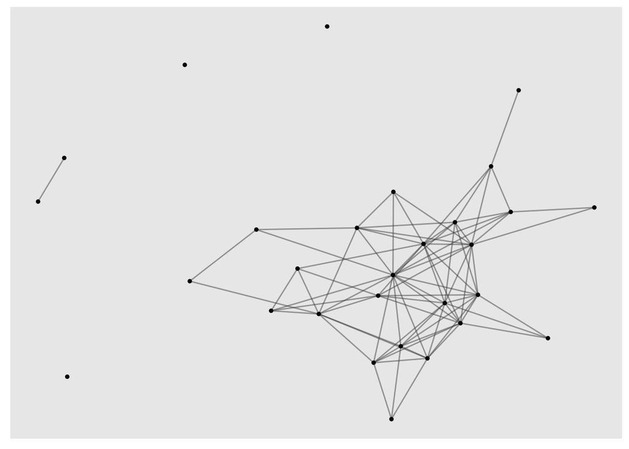

```r
collab_net %>%
  ggraph(layout = "fr") +
  geom_edge_link(
    colour = "grey30",
    width = .5,
    alpha = .5
  ) +
  geom_node_point(
    size = 1
  )
```

## 3.2 Support

### 3.2.1 Loading data

- Data on support relationships has a different structure
- It’s an **edgelist** (see [slides](https://federico-bianchi.github.io/sna/05.pdf))
- We still need to assign data to a matrix object (not an adjacency matrix, though)

Let’s first load the data

```r
(
support_df <-
  read_delim(
    file = here("data", "support.csv"),
    delim = " ",
    col_names = FALSE
  )
)
```

| X1 | X2 |
| --- | --- |
| V1 | V29 |
| V2 | V4 |
| V2 | V14 |
| V2 | V15 |
| V2 | V28 |
| V3 | V10 |
| V3 | V13 |
| V3 | V15 |
| V3 | V16 |
| V3 | V25 |

[output cut: 89 more lines]

```r
(support_net <- graph_from_edgelist(el = as.matrix(support_df)))
```

```
## IGRAPH 3f49f1c DN-- 28 99 --
## + attr: name (v/c)
## + edges from 3f49f1c (vertex names):
##  [1] V1 ->V29 V2 ->V4  V2 ->V14 V2 ->V15 V2 ->V28 V3 ->V10 V3 ->V13 V3 ->V15
##  [9] V3 ->V16 V3 ->V25 V3 ->V26 V3 ->V27 V4 ->V2  V5 ->V24 V6 ->V12 V6 ->V13
## [17] V6 ->V15 V6 ->V16 V6 ->V17 V6 ->V20 V6 ->V23 V7 ->V1  V7 ->V12 V8 ->V2
## [25] V8 ->V4  V8 ->V10 V8 ->V13 V8 ->V15 V8 ->V25 V8 ->V27 V8 ->V28 V9 ->V2
## [33] V9 ->V14 V10->V3  V10->V13 V10->V15 V10->V19 V10->V27 V12->V1  V12->V2
## [41] V12->V10 V12->V20 V13->V16 V14->V2  V14->V8  V14->V9  V14->V25 V15->V6
## [49] V15->V10 V15->V13 V15->V16 V15->V22 V16->V13 V16->V15 V16->V22 V17->V6
## [57] V17->V20 V18->V25 V19->V3  V19->V25 V19->V27 V20->V6  V20->V12 V20->V17
## + ... omitted several edges
```

- Why are nodes 28? We were expecting 29
- One of the nodes might be an *isolate*
- It’s always a good practice to store the list of edges and the list of nodes in two different objects, then integrate them in a graph object, unless you’re working on a connected component of a larger network
- The nodes are coded in the edge list file as “V1”, “V2”, …, “V29”
- So, we’ll generate a character vector by combining “V” with numbers between 1-29

We can then generate a graph object in a safer way through `graph_from_data_frame`, which takes a node list (vector) and and edge list (matrix) as inputs.

```r
(
support_net <-
  graph_from_data_frame(
     d = support_df,
     vertices = paste0("V", 1:29)
  )
)
```

```
## IGRAPH c9cd376 DN-- 29 99 --
## + attr: name (v/c)
## + edges from c9cd376 (vertex names):
##  [1] V1 ->V29 V2 ->V4  V2 ->V14 V2 ->V15 V2 ->V28 V3 ->V10 V3 ->V13 V3 ->V15
##  [9] V3 ->V16 V3 ->V25 V3 ->V26 V3 ->V27 V4 ->V2  V5 ->V24 V6 ->V12 V6 ->V13
## [17] V6 ->V15 V6 ->V16 V6 ->V17 V6 ->V20 V6 ->V23 V7 ->V1  V7 ->V12 V8 ->V2
## [25] V8 ->V4  V8 ->V10 V8 ->V13 V8 ->V15 V8 ->V25 V8 ->V27 V8 ->V28 V9 ->V2
## [33] V9 ->V14 V10->V3  V10->V13 V10->V15 V10->V19 V10->V27 V12->V1  V12->V2
## [41] V12->V10 V12->V20 V13->V16 V14->V2  V14->V8  V14->V9  V14->V25 V15->V6
## [49] V15->V10 V15->V13 V15->V16 V15->V22 V16->V13 V16->V15 V16->V22 V17->V6
## [57] V17->V20 V18->V25 V19->V3  V19->V25 V19->V27 V20->V6  V20->V12 V20->V17
## + ... omitted several edges
```

# 4 Connectivity

A basic *graph-level* network property we could be interested in is how *connected* a network is.

Let’s start from the number of edges

```r
ecount(collab_net)
```

```
## [1] 82
```

We can also retrieve the whole list of edges

```r
E(collab_net)
```

```
## + 82/82 edges from c303b09 (vertex names):
##  [1] X1 --X12 X2 --X4  X2 --X7  X2 --X8  X2 --X9  X2 --X10 X2 --X13 X2 --X14
##  [9] X2 --X15 X2 --X16 X3 --X6  X3 --X8  X3 --X9  X3 --X10 X3 --X14 X3 --X19
## [17] X3 --X20 X3 --X23 X3 --X25 X3 --X26 X3 --X27 X3 --X28 X4 --X9  X4 --X10
## [25] X4 --X14 X6 --X9  X6 --X10 X6 --X13 X6 --X15 X6 --X16 X6 --X17 X6 --X19
## [33] X6 --X20 X6 --X23 X7 --X21 X8 --X10 X8 --X19 X8 --X21 X8 --X27 X8 --X28
## [41] X9 --X14 X9 --X19 X9 --X20 X9 --X23 X10--X13 X10--X15 X10--X16 X10--X19
## [49] X10--X20 X10--X21 X10--X23 X10--X26 X10--X27 X10--X28 X13--X15 X13--X16
## [57] X13--X20 X13--X22 X13--X23 X15--X16 X15--X20 X15--X22 X15--X23 X16--X20
## [65] X16--X22 X17--X20 X17--X23 X18--X25 X19--X20 X19--X23 X19--X24 X19--X25
## [73] X19--X26 X19--X27 X19--X28 X20--X23 X20--X27 X23--X27 X24--X26 X25--X26
## + ... omitted several edges
```

The number of edges depends on the number of vertices

```r
vcount(collab_net)
```

```
## [1] 29
```

We can also retrieve the list of vertices

```r
V(collab_net)
```

```
## + 29/29 vertices, named, from c303b09:
##  [1] X1  X2  X3  X4  X5  X6  X7  X8  X9  X10 X11 X12 X13 X14 X15 X16 X17 X18 X19
## [20] X20 X21 X22 X23 X24 X25 X26 X27 X28 X29
```

## 4.1 Density

### 4.1.1 Collaboration

- In order to infer the level of *connectivity* from the number of edges, we need to compare it to the theoretically maximum value of possible links
- We combine each vertex with all other possible vertices
- Since our network is undirected, we divide by 2, so we don’t count pairs twice
- We’ll store the calculation output in a new object because we’re going to use it later again and we want to stay [D.R.Y.](https://en.wikipedia.org/wiki/Don%27t_repeat_yourself)

```r
(max_links <- vcount(collab_net) * (vcount(collab_net) - 1) / 2)
```

```
## [1] 406
```

Now, we can calculate the graph *density* as the ratio between the number of actual links and the number of possible links.

```r
ecount(collab_net) / max_links
```

```
## [1] 0.2019704
```

Actually, we don’t need to perform this calculation every time. There is a specific function in `igraph`

```r
edge_density(collab_net)
```

```
## [1] 0.2019704
```

- Is the density value high or low? Is our collaboration network *dense* or *sparse*?
- Let’s compare it to another network.

### 4.1.2 Support

Calculating density:

```r
edge_density(support_net)
```

```
## [1] 0.1219212
```

- Is the density value high or low?
- Are social networks capable of being fully connected?
- Are all relationships equal in terms of possible density?

# 5 Centrality

How (heterogeneously) *connected* are nodes?

- Which nodes are the most **important** ones?
- *Centrality* is a (rather vague) concept of (structural) importance within a network
- In a wider sense, a node’s degree can be seen as its *degree centrality*.

## 5.1 Degree centrality

### 5.1.1 Collaboration

The degree of a graph vertex is its number of edges (*=* size of its personal network)

Let’s look at the degree of our collaboration network

```r
igraph::degree(collab_net)
```

```
##  X1  X2  X3  X4  X5  X6  X7  X8  X9 X10 X11 X12 X13 X14 X15 X16 X17 X18 X19 X20
##   1   9  12   4   0  10   2   7   8  15   0   1   8   4   8   7   3   1  12  11
## X21 X22 X23 X24 X25 X26 X27 X28 X29
##   3   3  10   2   5   6   8   4   0
```

- This is the degree distribution
- It’s a numeric vector (each value comes with a label), so various operations can be applied on it

```r
sort(igraph::degree(collab_net), decreasing = TRUE)
```

```
## X10  X3 X19 X20  X6 X23  X2  X9 X13 X15 X27  X8 X16 X26 X25  X4 X14 X28 X17 X21
##  15  12  12  11  10  10   9   8   8   8   8   7   7   6   5   4   4   4   3   3
## X22  X7 X24  X1 X12 X18  X5 X11 X29
##   3   2   2   1   1   1   0   0   0
```

If we are interested in the relative degree:

```r
degree_distribution(collab_net)
```

```
##  [1] 0.10344828 0.10344828 0.06896552 0.10344828 0.10344828 0.03448276
##  [7] 0.03448276 0.06896552 0.13793103 0.03448276 0.06896552 0.03448276
## [13] 0.06896552 0.00000000 0.00000000 0.03448276
```

It’s easier to visualize it by using basic `R` plotting functions

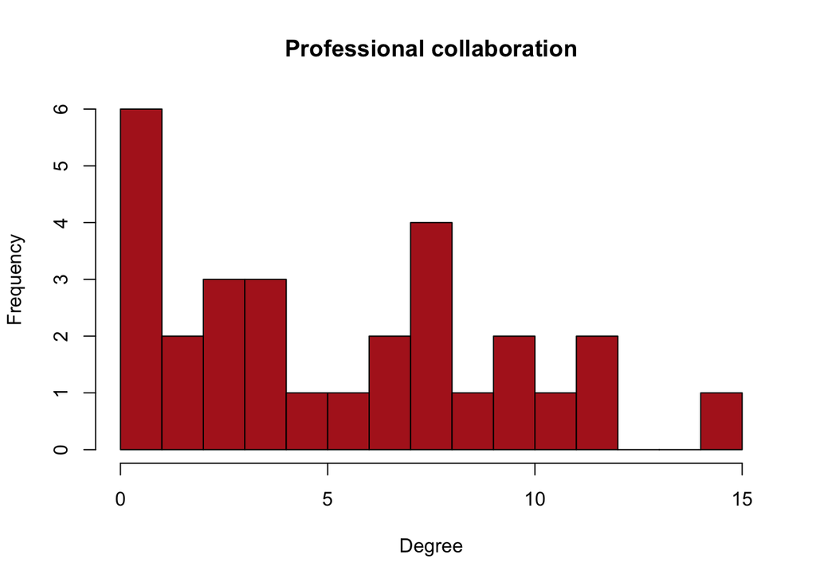

```r
collab_net %>%
  igraph::degree() %>%
  hist(
     col = "firebrick",
     xlab = "Degree",
     ylab = "Frequency",
     main = "Professional collaboration",
     breaks = min(.):max(.)
  )
```

A more elegant graph can be plotted with `ggplot2`

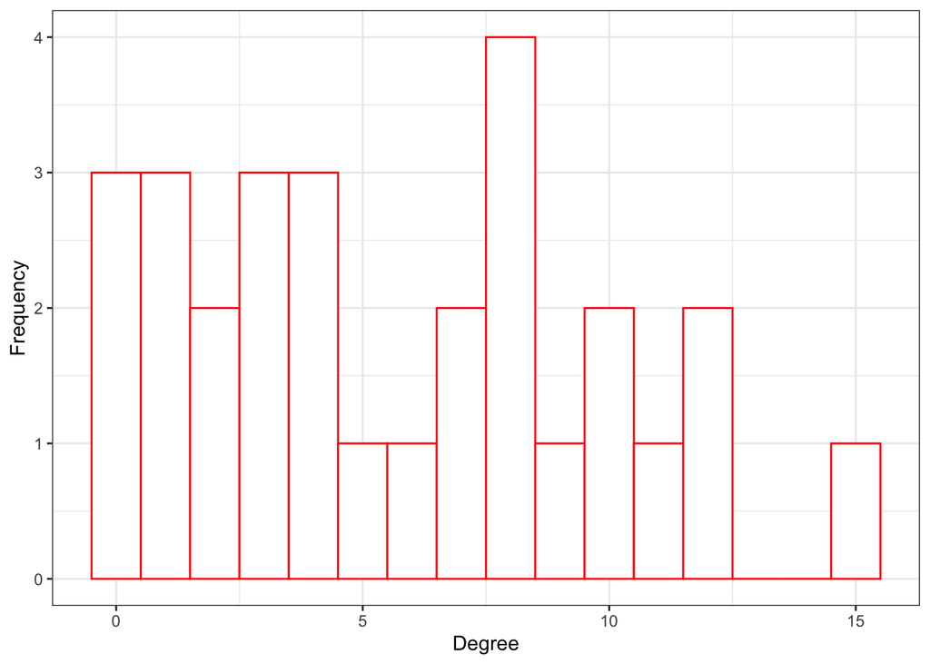

```r
collab_net %>%
  igraph::degree() %>%
  as.tibble() %>%
  ggplot() +
  geom_histogram(
    aes(value),
    binwidth = 1,
    color = "red",
    fill = "white"
  ) +
  theme_bw() +
  xlab("Degree") +
  ylab("Frequency")
```

### 5.1.2 Support

If the network is directed: * in-degree (*popularity*): number of arcs directed to a vertex * out-degree (*activity*): number of arcs directed away from a vertex

Let’s look at the support network

```r
igraph::degree(support_net, mode = "in")
```

```
##  V1  V2  V3  V4  V5  V6  V7  V8  V9 V10 V11 V12 V13 V14 V15 V16 V17 V18 V19 V20
##   4   6   3   4   1   5   1   2   2   7   0   5   7   2   7   5   3   0   5   5
## V21 V22 V23 V24 V25 V26 V27 V28 V29
##   1   2   2   2   7   1   6   2   2
```

Visualization of the in-degree

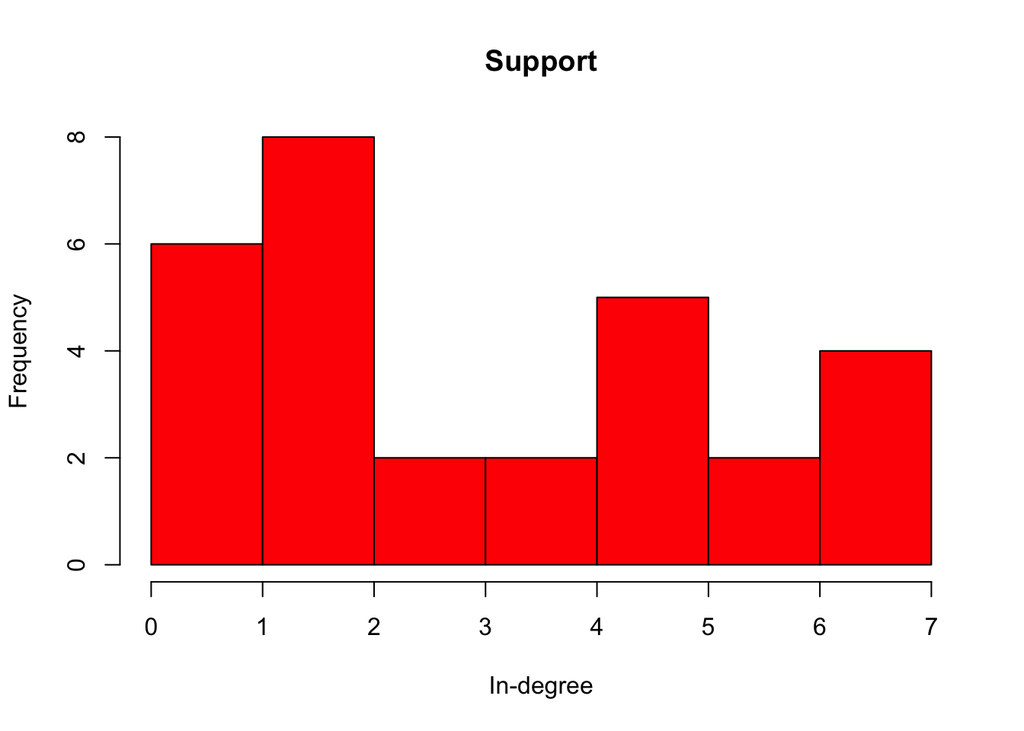

```r
support_net %>%
  igraph::degree(mode = "in") %>%
  hist(,
     col = "red",
     xlab = "In-degree",
     ylab = "Frequency",
     main = "Support",
     breaks = min(.):max(.)
  )
```

Visualization of the out-degree

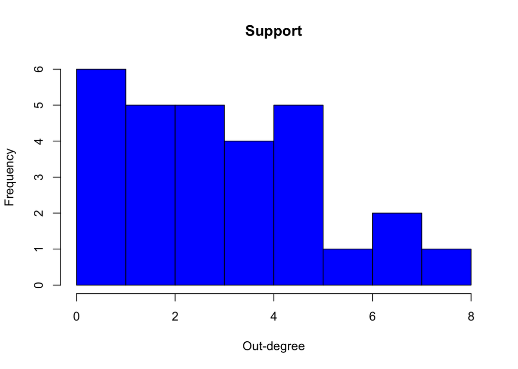

```r
support_net %>%
  igraph::degree(mode = "out") %>%
  hist(
     col = "blue",
     xlab = "Out-degree",
     ylab = "Frequency",
     main = "Support",
     breaks = min(.):max(.)
  )
```

Let’s plot both degree directions in the same chart: * We need `ggplot()`, which applies to `data.frames` or `tibbles` * Create a `tibble` with two columns (in- and out-degree) * To plot two variables in the same chart, we need to make it a tidy, longer dataset: 1. Each variable must have its own column. 2. Each observation must have its own row. 3. Each value must have its own cell. * change dataset form to a longer form with degree in one variable and direction as the other variable * now we can apply `ggplot`

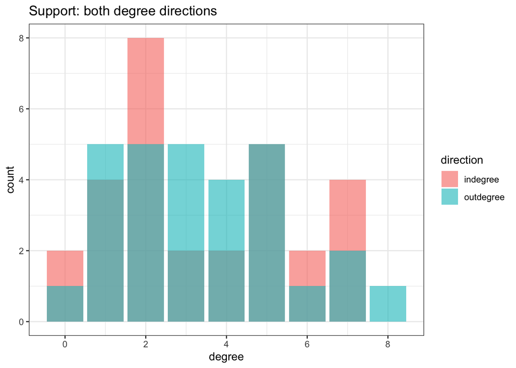

```r
tibble(
  indegree = igraph::degree(support_net, mode = "in"),
  outdegree = igraph::degree(support_net, mode = "out")
) %>%
  pivot_longer(
    cols = everything(),
    names_to = "direction",
    values_to = "degree"
  ) %>%
  ggplot(aes(x = degree, fill = direction)) +
  geom_bar(position = "identity", alpha = .6) +
  theme_bw() +
  ggtitle("Support: both degree directions")
```

## 5.2 Node attributes

- We might want to analyse whether different degree values are linked to the subjects’ individual properties.
- We need to analyse node attributes

First, we need to load data on nodal attributes.

```r
(node_attributes <- read_csv2(file = here("data", "node-attributes.csv")))
```

| ...1 | id | education | age | age3 | gender | seniority | seniority_rec | family | children | soc_capital | satisfaction |
| --- | --- | --- | --- | --- | --- | --- | --- | --- | --- | --- | --- |
| 1 | V1 | lower secondary | 40 | 2 | M | 17 | 1 | single | no | 2 | 5 |
| 2 | V2 | upper secondary | 41 | 2 | M | 46 | 3 | cohabitant with partner | no | 2 | 4 |
| 3 | V3 | tertiary | 25 | 0 | F | 39 | 3 | single | no | NA | 4 |
| 4 | V4 | tertiary | 28 | 0 | M | 25 | 2 | in a stable relationship | no | 2 | 3 |
| 5 | V5 | tertiary | 28 | 0 | M | 7 | 0 | in a stable relationship | no | 0 | 3 |
| 6 | V6 | tertiary | 31 | 1 | M | 43 | 3 | married | no | 13 | 5 |
| 7 | V7 | post-graduate | 39 | 1 | M | 17 | 1 | married | yes | 0 | 4 |
| 8 | V8 | tertiary | 28 | 0 | M | 46 | 3 | cohabitant with partner | no | 7 | 3 |
| 9 | V9 | upper secondary | 31 | 1 | M | 28 | 2 | single | no | 4 | 5 |
| 10 | V10 | upper secondary | 28 | 0 | M | 46 | 3 | single | no | 6 | 6 |

[output cut: 19 more lines]

Now we can integrate the dataset with node attributes to the graph objects.

```r
vertex_attr(support_net) <- vertex_attr(collab_net) <- node_attributes
```

Since we’re going to use `tbl_graph` objects again, we’ll define new objects

```r
collab_tblgr <- as_tbl_graph(collab_net)
support_tblgr <- as_tbl_graph(support_net)
```

Node attributes can be inspected

```r
collab_tblgr %>%
  as_tibble() %>%
  summarise(
    mean_age = mean(age),
    sd_age = sd(age)
  )
```

| mean_age | sd_age |
| --- | --- |
| 31.82759 | 6.041931 |

… and plotted

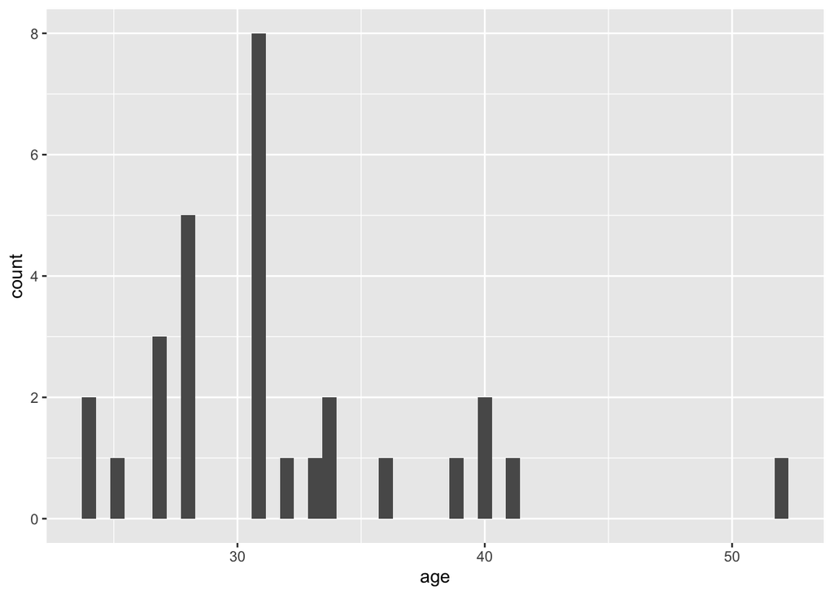

```r
collab_tblgr %>%
  as_tibble() %>%
  ggplot() +
  geom_histogram(
    mapping = aes(age),
    bins = 50
  )
```

Plot support w/ attributes

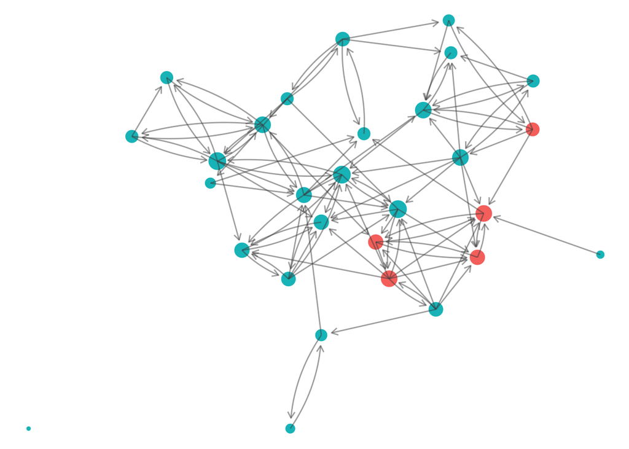

```r
support_net %>%
  ggraph(layout = "auto") +
  geom_node_point(
    aes(
      size = igraph::degree(support_net),
      color = gender
    ),
    show.legend = FALSE
  ) +
  # geom_edge_link() +
  geom_edge_fan(
    arrow = arrow(length = unit(2, "mm")),
    end_cap = circle(3, "mm"),
    color = "grey30",
    width = .5,
    alpha = .5
  ) +
  theme_void()
```

Adding degree centrality as a node attribute. We’re going to use a new operator from the `magrittr` package

```r
collab_tblgr %<>%
  mutate(degree = centrality_degree())

support_tblgr %<>%
  mutate(degree = centrality_degree())
```

We can explore correlations

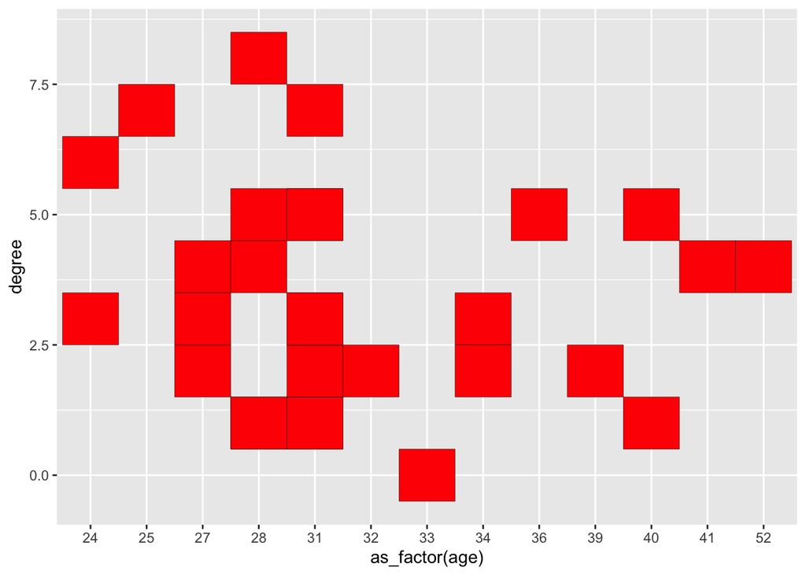

```r
support_tblgr %>%
  as_tibble() %>%
  ggplot(aes(as_factor(age), degree)) +
  geom_tile(color = "black", fill = "red")
```

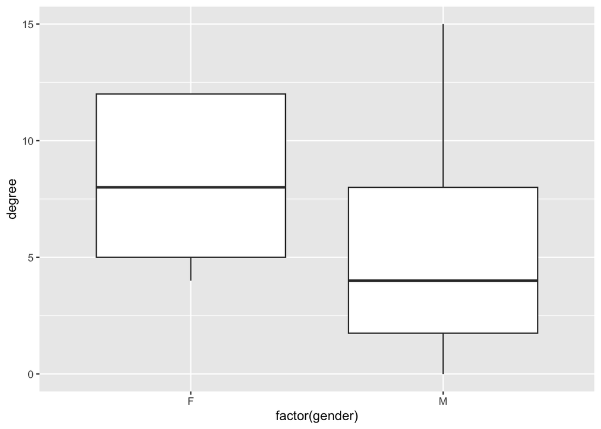

```r
collab_tblgr %>%
  as_tibble() %>%
  ggplot() +
  geom_boxplot(aes(factor(gender), degree))
```

## 5.3 Eigenvector centrality

Let’s load a new network dataset

```r
(
net1 <-
  here("data", "cent_example_1.rds") %>%
  read_rds()
)
```

```
## IGRAPH e0b5591 U--- 11 17 --
## + attr: cent (v/n)
## + edges from e0b5591:
##  [1] 1--11 2-- 4 3-- 5 3--11 4-- 8 5-- 9 5--11 6-- 7 6-- 8 6--10 6--11 7-- 9
## [13] 7--10 7--11 8-- 9 8--10 9--10
```

```r
net1 %<>%
  as_tbl_graph() %>%
  mutate(name = 1:vcount(.))

net1_plot <-
  net1 %>%
  ggraph(layout = "auto") +
  geom_edge_link(
    color = "grey",
    width = .5
  ) +
  geom_node_text(aes(label = name))
```

```
## Using "stress" as default layout
```

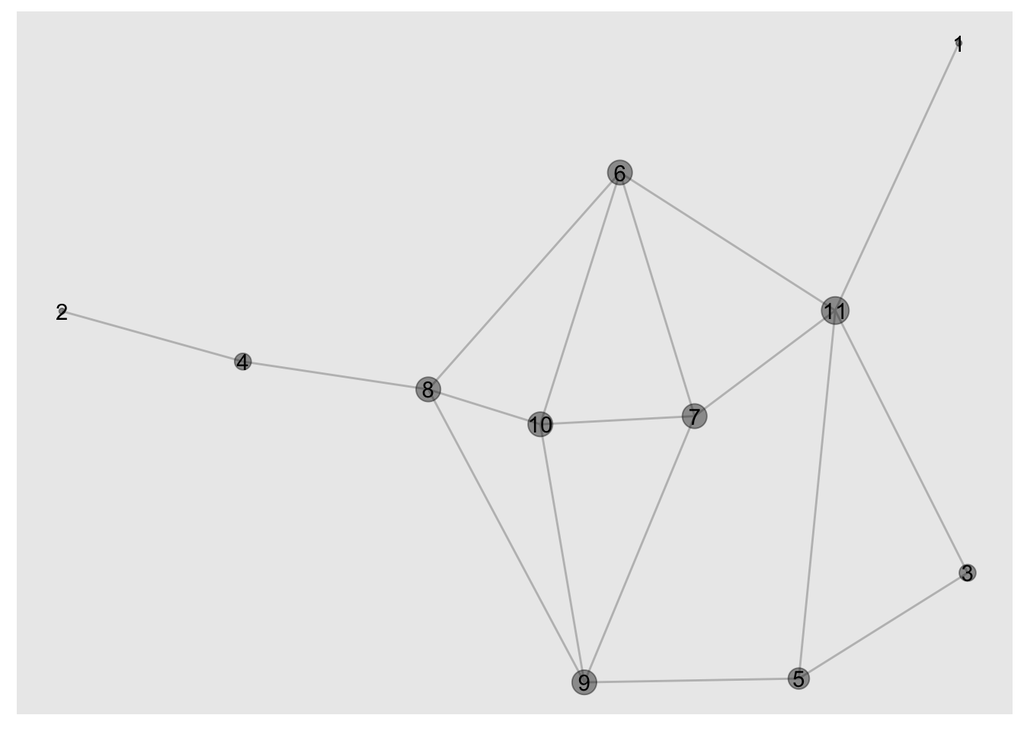

```r
net1_plot +
  geom_node_point(
    aes(size = igraph::degree(net1)),
    alpha = .4,
    show.legend = F
  )
```

Degree distribution:

```r
sort(igraph::degree(net1), decreasing = T)
```

```
## 11  6  7  8  9 10  5  3  4  1  2
##  5  4  4  4  4  4  3  2  2  1  1
```

Who would you choose for a policy intervention to let something diffuse more rapidly?

We need to calculate *eigenvector centrality* (see slides)

```r
eigen_centrality(net1)
```

```
## $vector
##         1         2         3         4         5         6         7         8
## 0.2259630 0.0645825 0.3786244 0.2415182 0.5709057 0.9846544 1.0000000 0.8386195
##         9        10        11
## 0.9113529 0.9986474 0.8450304
##
## $value
## [1] 3.739685
##
## $options
## $options$bmat
## [1] "I"
##
## $options$n
## [1] 11
##
## $options$which
## [1] "LA"
##
## $options$nev
## [1] 1
##
## $options$tol
## [1] 0
##
## $options$ncv
## [1] 0
##
## $options$ldv
## [1] 0
##
## $options$ishift
## [1] 1
##
## $options$maxiter
## [1] 3000
##
## $options$nb
## [1] 1
##
```

[output cut: 14 more lines]

```
##
## $options$iter
## [1] 8
##
## $options$nconv
## [1] 1
##
## $options$numop
## [1] 26
##
## $options$numopb
## [1] 0
##
## $options$numreo
## [1] 11
```

In case of a directed network, indegree is considered

```r
eigen_centrality(support_net, directed = T)$vector
```

```
##  [1] 2.613812e-01 1.879366e-01 3.558680e-01 9.851569e-02 7.909163e-03
##  [6] 5.092964e-01 5.809195e-03 3.359210e-02 3.817411e-02 5.997657e-01
## [11] 1.836642e-17 3.931440e-01 1.000000e+00 6.194062e-02 8.253794e-01
## [16] 8.638070e-01 3.272524e-01 1.836642e-17 6.018240e-01 4.284375e-01
## [21] 2.120614e-02 4.627346e-01 2.568822e-01 2.887195e-02 4.777923e-01
## [26] 9.748625e-02 5.934425e-01 6.068543e-02 7.741179e-02
```

Let’s plot the network by eigenvector centrality

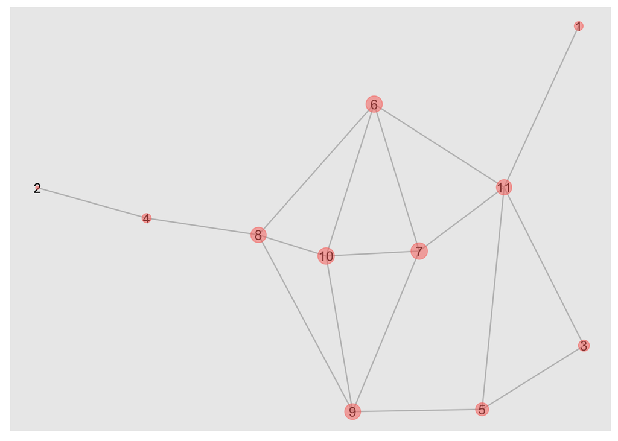

```r
net1_plot +
  geom_node_point(
    aes(
      size = eigen_centrality(net1)$vector,
      color = "red",
      alpha = .5
    ),
    show.legend = FALSE
  )
```

Let’s compare degree and eigenvector centrality

```r
net1 %>%
  as_tbl_graph() %>%
  mutate(
    deg = centrality_degree(),
    eigen = centrality_eigen()
  ) %>%
  as_tibble() %>%
  select(name, deg, eigen) %>%
  arrange(-deg)
```

| name | deg | eigen |
| --- | --- | --- |
| 11 | 5 | 0.8450304 |
| 6 | 4 | 0.9846544 |
| 7 | 4 | 1.0000000 |
| 8 | 4 | 0.8386195 |
| 9 | 4 | 0.9113529 |
| 10 | 4 | 0.9986474 |
| 5 | 3 | 0.5709057 |
| 3 | 2 | 0.3786244 |
| 4 | 2 | 0.2415182 |
| 1 | 1 | 0.2259630 |

[output cut: 1 more lines]

## 5.4 Betweenness centrality

Let’s calculate betweenness centrality (see slides)

```r
igraph::betweenness(net1, directed = FALSE, normalized = TRUE)
```

```
##          1          2          3          4          5          6          7
## 0.00000000 0.00000000 0.00000000 0.20000000 0.08518519 0.21851852 0.05925926
##          8          9         10         11
## 0.36296296 0.16296296 0.02962963 0.32592593
```

Let’s plot the network by betweenness centrality

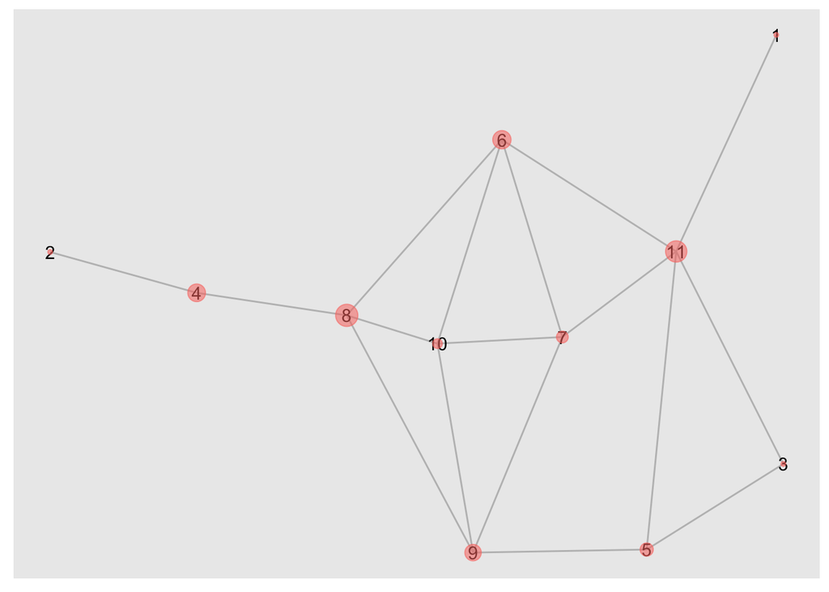

```r
net1_plot +
  geom_node_point(
    aes(
      size = igraph::betweenness(net1, directed = FALSE, normalized = TRUE),
      color = "red",
      alpha = .5
    ),
    show.legend = FALSE
  )
```

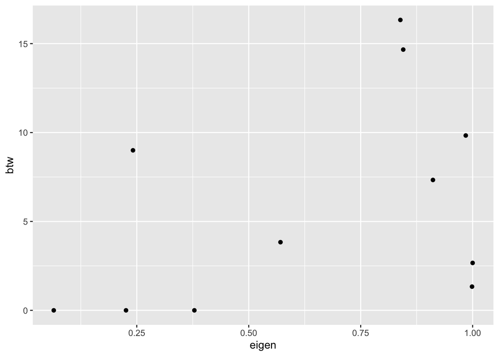

```r
net1 %>%
  as_tbl_graph() %>%
  mutate(
    deg = centrality_degree(),
    eigen = centrality_eigen(),
    btw = centrality_betweenness(directed = FALSE)
  ) %>%
  as_tibble() %>%
  # select(name, deg, eigen, btw) %>%
  # arrange(-deg)
  ggplot(aes(eigen, btw)) +
  geom_point(color = "black", fill = "transparent")
```

## 5.5 Exercise

Loading data

```r
(
advice_df <-
  here("data", "advice-coworking.txt") %>%
  read_tsv(col_names = FALSE)
)
```

| X1 | X2 | X3 | X4 | X5 | X6 | X7 | X8 | X9 | X10 | X11 | X12 | X13 | X14 | X15 | X16 | X17 | X18 | X19 | X20 | X21 | X22 | X23 | X24 | X25 | X26 | X27 | X28 | X29 |
| --- | --- | --- | --- | --- | --- | --- | --- | --- | --- | --- | --- | --- | --- | --- | --- | --- | --- | --- | --- | --- | --- | --- | --- | --- | --- | --- | --- | --- |
| 0 | 1 | 0 | 0 | 0 | 0 | 0 | 0 | 0 | 0 | 0 | 1 | 0 | 0 | 0 | 0 | 0 | 0 | 0 | 0 | 0 | 0 | 0 | 0 | 0 | 0 | 0 | 0 | 0 |
| 0 | 0 | 0 | 1 | 0 | 0 | 0 | 1 | 0 | 0 | 0 | 0 | 1 | 0 | 1 | 1 | 0 | 0 | 0 | 0 | 0 | 0 | 0 | 0 | 0 | 0 | 0 | 1 | 0 |
| 0 | 0 | 0 | 0 | 0 | 1 | 0 | 0 | 0 | 1 | 0 | 0 | 0 | 0 | 1 | 1 | 0 | 0 | 1 | 1 | 0 | 0 | 1 | 0 | 1 | 1 | 0 | 0 | 0 |
| 1 | 1 | 0 | 0 | 0 | 0 | 0 | 0 | 0 | 0 | 0 | 0 | 0 | 0 | 1 | 0 | 0 | 0 | 0 | 0 | 0 | 0 | 0 | 0 | 0 | 0 | 1 | 1 | 0 |
| 0 | 0 | 0 | 0 | 0 | 0 | 0 | 0 | 1 | 0 | 0 | 0 | 0 | 0 | 0 | 0 | 0 | 0 | 0 | 0 | 0 | 0 | 0 | 1 | 0 | 0 | 0 | 0 | 0 |
| 0 | 0 | 0 | 0 | 0 | 0 | 0 | 0 | 0 | 0 | 0 | 0 | 1 | 0 | 1 | 1 | 1 | 0 | 0 | 1 | 1 | 0 | 1 | 0 | 0 | 0 | 0 | 0 | 0 |
| 0 | 1 | 0 | 0 | 0 | 0 | 0 | 0 | 0 | 0 | 0 | 0 | 0 | 0 | 0 | 0 | 0 | 0 | 0 | 0 | 0 | 0 | 0 | 0 | 0 | 0 | 0 | 0 | 0 |
| 0 | 1 | 0 | 1 | 0 | 0 | 0 | 0 | 0 | 0 | 0 | 0 | 1 | 0 | 1 | 0 | 0 | 0 | 0 | 0 | 0 | 0 | 0 | 0 | 0 | 0 | 0 | 1 | 0 |
| 0 | 1 | 0 | 1 | 0 | 1 | 0 | 0 | 0 | 0 | 0 | 0 | 0 | 1 | 1 | 0 | 0 | 0 | 0 | 0 | 0 | 0 | 1 | 0 | 0 | 0 | 0 | 0 | 0 |
| 0 | 0 | 1 | 0 | 0 | 0 | 0 | 0 | 0 | 0 | 0 | 0 | 1 | 0 | 1 | 1 | 0 | 0 | 1 | 0 | 1 | 0 | 0 | 0 | 1 | 0 | 0 | 0 | 0 |

[output cut: 19 more lines]

Turning the data frame into a graph

```r
(
advice_net <-
  advice_df %>%
  as.matrix() %>%
  graph_from_adjacency_matrix()
)
```

```
## IGRAPH 531c8b5 DN-- 29 120 --
## + attr: name (v/c)
## + edges from 531c8b5 (vertex names):
##  [1] X1 ->X2  X1 ->X12 X2 ->X4  X2 ->X8  X2 ->X13 X2 ->X15 X2 ->X16 X2 ->X28
##  [9] X3 ->X6  X3 ->X10 X3 ->X15 X3 ->X16 X3 ->X19 X3 ->X20 X3 ->X23 X3 ->X25
## [17] X3 ->X26 X4 ->X1  X4 ->X2  X4 ->X15 X4 ->X27 X4 ->X28 X5 ->X9  X5 ->X24
## [25] X6 ->X13 X6 ->X15 X6 ->X16 X6 ->X17 X6 ->X20 X6 ->X21 X6 ->X23 X7 ->X2
## [33] X8 ->X2  X8 ->X4  X8 ->X13 X8 ->X15 X8 ->X28 X9 ->X2  X9 ->X4  X9 ->X6
## [41] X9 ->X14 X9 ->X15 X9 ->X23 X10->X3  X10->X13 X10->X15 X10->X16 X10->X19
## [49] X10->X21 X10->X25 X11->X15 X12->X2  X12->X6  X12->X7  X13->X15 X13->X16
## [57] X14->X2  X14->X4  X14->X9  X14->X25 X15->X6  X15->X13 X15->X16 X15->X21
## + ... omitted several edges
```

Adding node attributes

```r
vertex_attr(advice_net) <- node_attributes
```

Tibble graph object

```r
(advice_tblgr <- as_tbl_graph(advice_net))
```

```
## # A tbl_graph: 29 nodes and 120 edges
## #
## # A directed simple graph with 1 component
## #
## # A tibble: 29 × 12
##    ...1 id    education         age  age3 gender seniority seniority_rec family
##   <dbl> <chr> <chr>           <dbl> <dbl> <chr>      <dbl>         <dbl> <chr>
## 1     1 V1    lower secondary    40     2 M             17             1 single
## 2     2 V2    upper secondary    41     2 M             46             3 cohabi…
## 3     3 V3    tertiary           25     0 F             39             3 single
## 4     4 V4    tertiary           28     0 M             25             2 in a s…
## 5     5 V5    tertiary           28     0 M              7             0 in a s…
## 6     6 V6    tertiary           31     1 M             43             3 married
## # ℹ 23 more rows
## # ℹ 3 more variables: children <chr>, soc_capital <dbl>, satisfaction <dbl>
## #
## # A tibble: 120 × 2
##    from    to
##   <int> <int>
## 1     1     2
## 2     1    12
## 3     2     4
## # ℹ 117 more rows
```

Possible descriptive analysis:

```r
(
advice_tblgr %<>%
  mutate(
    in_deg_cen = centrality_degree(mode = "in"),
    out_deg_cen = centrality_degree(mode = "out"),
    eigen_cen = centrality_eigen(directed = TRUE),
    btw_cen = centrality_betweenness()
  )
)
```

```
## # A tbl_graph: 29 nodes and 120 edges
## #
## # A directed simple graph with 1 component
## #
## # A tibble: 29 × 16
##    ...1 id    education         age  age3 gender seniority seniority_rec family
##   <dbl> <chr> <chr>           <dbl> <dbl> <chr>      <dbl>         <dbl> <chr>
## 1     1 V1    lower secondary    40     2 M             17             1 single
## 2     2 V2    upper secondary    41     2 M             46             3 cohabi…
## 3     3 V3    tertiary           25     0 F             39             3 single
## 4     4 V4    tertiary           28     0 M             25             2 in a s…
## 5     5 V5    tertiary           28     0 M              7             0 in a s…
## 6     6 V6    tertiary           31     1 M             43             3 married
## # ℹ 23 more rows
## # ℹ 7 more variables: children <chr>, soc_capital <dbl>, satisfaction <dbl>,
## #   in_deg_cen <dbl>, out_deg_cen <dbl>, eigen_cen <dbl>, btw_cen <dbl>
## #
## # A tibble: 120 × 2
##    from    to
##   <int> <int>
## 1     1     2
## 2     1    12
## 3     2     4
## # ℹ 117 more rows
```

- note that eigenvector centrality is calculated on the left eigenvector (in-degree, which makes sense because it’s advice-seeking). if you want out-degree, you need the right eigenvector, so run the function on the transpose of the adjacency matrix `eigen_centrality(t(get.adjacency(advice_net, sparse=FALSE)))`

Measurements could be scaled

```r
scale <- function(cent) {
  min_cent <- min(cent)
  max_cent <- max(cent)
  scaled_cent <- (cent - min_cent) / (max_cent - min_cent)
  return(scaled_cent)
}

advice_tblgr %<>%
  mutate(
    across(ends_with("cen") & !starts_with("eigen"), scale)
  )

advice_tblgr %>%
  as_tibble() %>%
  select(id, ends_with("cen")) %>%
  arrange(-in_deg_cen)
```

| id | in_deg_cen | out_deg_cen | eigen_cen | btw_cen |
| --- | --- | --- | --- | --- |
| V15 | 1.0000 | 0.4 | 1.0000000000 | 0.720946048 |
| V6 | 0.6250 | 0.6 | 0.9455922289 | 0.456296123 |
| V13 | 0.5625 | 0.1 | 0.7072197013 | 0.194088456 |
| V2 | 0.5000 | 0.5 | 0.0550463182 | 0.739227055 |
| V16 | 0.5000 | 0.5 | 0.7421183945 | 1.000000000 |
| V20 | 0.5000 | 0.2 | 0.8017888629 | 0.428158644 |
| V23 | 0.4375 | 0.2 | 0.6511911078 | 0.083995834 |
| V19 | 0.3750 | 1.0 | 0.3745949724 | 0.940695751 |
| V4 | 0.3125 | 0.4 | 0.0380985598 | 0.780250297 |
| V25 | 0.3125 | 0.1 | 0.2245325239 | 0.062028327 |

[output cut: 19 more lines]

```r
(
advice_tblgr %<>%
  mutate(
    in_deg_cen = centrality_degree(mode = "in"),
    out_deg_cen = centrality_degree(mode = "out"),
    eigen_cen = centrality_eigen(directed = TRUE),
    btw_cen = centrality_betweenness()
  )
)
```

```
## # A tbl_graph: 29 nodes and 120 edges
## #
## # A directed simple graph with 1 component
## #
## # A tibble: 29 × 16
##    ...1 id    education         age  age3 gender seniority seniority_rec family
##   <dbl> <chr> <chr>           <dbl> <dbl> <chr>      <dbl>         <dbl> <chr>
## 1     1 V1    lower secondary    40     2 M             17             1 single
## 2     2 V2    upper secondary    41     2 M             46             3 cohabi…
## 3     3 V3    tertiary           25     0 F             39             3 single
## 4     4 V4    tertiary           28     0 M             25             2 in a s…
## 5     5 V5    tertiary           28     0 M              7             0 in a s…
## 6     6 V6    tertiary           31     1 M             43             3 married
## # ℹ 23 more rows
## # ℹ 7 more variables: children <chr>, soc_capital <dbl>, satisfaction <dbl>,
## #   in_deg_cen <dbl>, out_deg_cen <dbl>, eigen_cen <dbl>, btw_cen <dbl>
## #
## # A tibble: 120 × 2
##    from    to
##   <int> <int>
## 1     1     2
## 2     1    12
## 3     2     4
## # ℹ 117 more rows
```

```r
advice_tblgr %>%
  as_tibble() %>%
  select(ends_with("cen"))
```

| in_deg_cen | out_deg_cen | eigen_cen | btw_cen |
| --- | --- | --- | --- |
| 2 | 2 | 0.0077012515 | 32.450000 |
| 8 | 6 | 0.0550463182 | 95.761905 |
| 4 | 9 | 0.3020603775 | 88.308009 |
| 5 | 5 | 0.0380985598 | 101.076190 |
| 1 | 2 | 0.0038684813 | 73.000000 |
| 10 | 7 | 0.9455922289 | 59.110101 |
| 2 | 1 | 0.0915313658 | 26.785714 |
| 3 | 5 | 0.0945157263 | 60.916667 |
| 2 | 6 | 0.0008152889 | 73.066667 |
| 3 | 7 | 0.2867912467 | 18.701587 |

[output cut: 19 more lines]

*note*: social capital means outside social capital

Various possible bivariates: * seniority is associated with both support and advice eigenvector centrality (the more senior, the more i am considered a source of support and advice) * same for education * social capital associated to advice, less support * same for satisfaction * no such thing for age * no clear picture on betweenness centrality

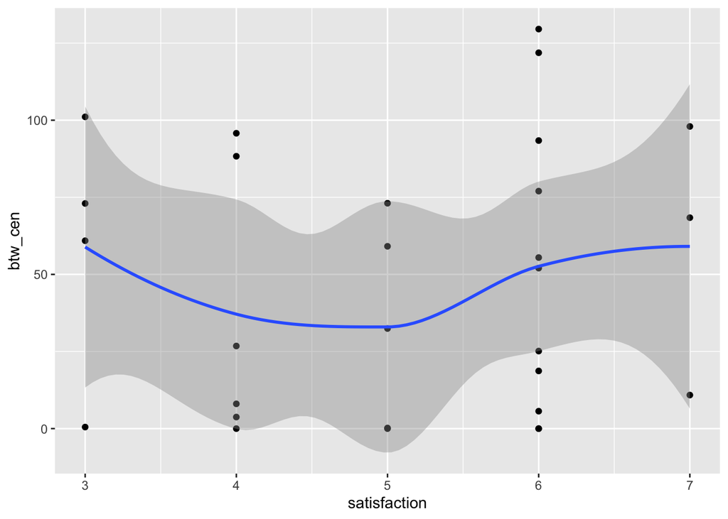

```r
advice_tblgr %>%
  as_tibble() %>%
  ggplot(aes(satisfaction, btw_cen)) +
  # geom_boxplot()
  geom_point() +
  geom_smooth()
```

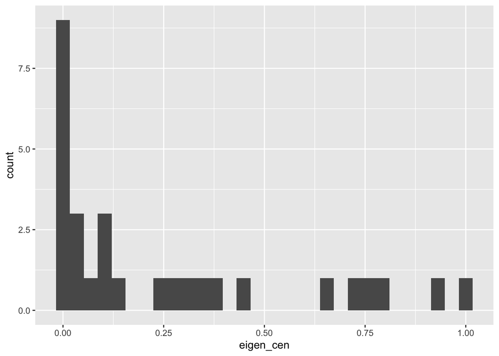

```r
advice_tblgr %>%
  as_tibble() %>%
  ggplot(aes(eigen_cen)) +
  geom_histogram()
```

# 6 Analysing ego-centric data

- brief recap on what ego-network analysis is:
  - a sample of subjects (egos)
  - for each ego, we have a network
    - the network’s nodes are alters
    - the network’s ties (not always present) are alter-alter ties
  - in simplest cases, no ties across egos
- we’re going to work on the Sociable ego-network data (slightly modified)
- download files
- three files (show them):
  - egos’ attributes
  - alters’ attributes (no ego-alter list is needed because ego-alter ties are implicit in the alters’ file)
  - alter-alter edgelist with possible edge attributes

Node attributes

```r
(ego_attr <- read_csv2(file = here("data", "ego-class.csv")))
```

```
## ℹ Using "','" as decimal and "'.'" as grouping mark. Use `read_delim()` for more control.
```

| ego_id | random | age | gender | marital | educ | occ.typ | tel.int | dis.phys.count.cat | hcare.count.cat | adl.rec | gds.rec | demen | rsa | mmse |
| --- | --- | --- | --- | --- | --- | --- | --- | --- | --- | --- | --- | --- | --- | --- |
| 1 | No | 84 | Male | Not married | middle | 3. Retail/office employee | No | One | None | No | >1 | Yes | No | 30 |
| 2 | No | 81 | Male | Married | primary | 1. Elementary/menial | No | One | None | No | 0 | No | No | 28 |
| 3 | No | 83 | Male | Married | primary | 3. Retail/office employee | No | Multiple | None | No | 0 | No | No | 29 |
| 4 | No | 77 | Female | Married | primary | 1. Elementary/menial | No | One | None | No | >1 | No | No | 28 |
| 5 | No | 93 | Male | Married | primary | 1. Elementary/menial | No | Multiple | Multiple | No | 0 | No | No | 28 |
| 6 | Yes | 88 | Female | Married | primary | 2. Skilled crafts/trades | No | One | None | No | 0 | No | No | 29 |
| 7 | No | 81 | Male | Married | middle | 2. Skilled crafts/trades | No | One | One | No | 0 | No | No | 29 |
| 8 | No | 79 | Female | Married | middle | 2. Skilled crafts/trades | No | Multiple | One | No | 1 | No | No | 29 |
| 9 | No | 79 | Male | Married | primary | 2. Skilled crafts/trades | No | None | None | No | 0 | No | No | 28 |
| 10 | No | 84 | Male | Not married | middle | 2. Skilled crafts/trades | No | None | Multiple | No | 1 | No | No | 27 |

[output cut: 219 more lines]

Alters’ attributes

```r
(alter_attr <- read_csv(file = here("data", "alter-data.csv")))
```

| ego_id | alter_id | freq.rec | week.daily | alter.sex | alter.cores | role | role.rec | intgen |
| --- | --- | --- | --- | --- | --- | --- | --- | --- |
| 1 | 101 | yearly | No | Male | No | child | imm.fam | Yes |
| 1 | 102 | yearly | No | Male | No | child | imm.fam | Yes |
| 1 | 103 | yearly | No | Male | No | child | imm.fam | Yes |
| 1 | 104 | yearly | No | Male | No | child | imm.fam | Yes |
| 1 | 105 | yearly | No | Male | No | child | imm.fam | Yes |
| 1 | 106 | weekly | Yes | Female | No | child | imm.fam | Yes |
| 1 | 107 | daily | Yes | Female | No | oth.fam | ext.fam | No |
| 2 | 201 | daily | Yes | Female | Yes | spouse | imm.fam | No |
| 2 | 202 | daily | Yes | Male | Yes | child | imm.fam | Yes |
| 2 | 203 | weekly | Yes | Male | No | child | imm.fam | Yes |

[output cut: 2719 more lines]

Alter-alter ties

```r
(alter_alter <- read_csv(here("data", "alter-ties.csv")))
```

| ego_id | altsource_id | alttarg_id |
| --- | --- | --- |
| 1 | 101 | 102 |
| 1 | 101 | 103 |
| 1 | 101 | 104 |
| 1 | 101 | 105 |
| 1 | 101 | 106 |
| 1 | 102 | 103 |
| 1 | 102 | 104 |
| 1 | 102 | 105 |
| 1 | 102 | 106 |
| 1 | 103 | 104 |

[output cut: 8293 more lines]

- Research question: is network *complexity*, rather than size, beneficial for older adults’ cognitive abilities?
- We need to compute graph-level measures (complexity and size)
- We could code a loop that subsets `alter_alter` by `ego_id` and turn each ego-network into an `igraph` object

More efficient: creating an `egor` object and generating a list of igraph networks

```r
(
whole_df <-
  threefiles_to_egor(
    egos = ego_attr,
    alters.df = alter_attr,
    edges = alter_alter,
    ID.vars = list(
      ego = "ego_id",
      alter = "alter_id",
      source = "altsource_id",
      target = "alttarg_id"
    )
  )
)
```

```
## # EGO data (active): 229 × 15
##   .egoID random   age gender marital    educ  occ.typ tel.int dis.phys.count.cat
## *  <dbl> <chr>  <dbl> <chr>  <chr>      <chr> <chr>   <chr>   <chr>
## 1      1 No        84 Male   Not marri… midd… 3. Ret… No      One
## 2      2 No        81 Male   Married    prim… 1. Ele… No      One
## 3      3 No        83 Male   Married    prim… 3. Ret… No      Multiple
## 4      4 No        77 Female Married    prim… 1. Ele… No      One
## 5      5 No        93 Male   Married    prim… 1. Ele… No      Multiple
## # ℹ 224 more rows
## # ℹ 6 more variables: hcare.count.cat <chr>, adl.rec <chr>, gds.rec <chr>,
## #   demen <chr>, rsa <chr>, mmse <dbl>
## # ALTER data: 2,729 × 9
##   .altID .egoID freq.rec week.daily alter.sex alter.cores role  role.rec intgen
## *  <dbl>  <dbl> <chr>    <chr>      <chr>     <chr>       <chr> <chr>    <chr>
## 1    101      1 yearly   No         Male      No          child imm.fam  Yes
## 2    102      1 yearly   No         Male      No          child imm.fam  Yes
## 3    103      1 yearly   No         Male      No          child imm.fam  Yes
## # ℹ 2,726 more rows
## # AATIE data: 8,303 × 3
##   .egoID .srcID .tgtID
## *  <dbl>  <dbl>  <dbl>
## 1      1    101    102
## 2      1    101    103
## 3      1    101    104
## # ℹ 8,300 more rows
```

What kind of object is it?

Different parts can be inspected

```r
whole_df[[3]]
```

| .egoID | .srcID | .tgtID |
| --- | --- | --- |
| 1 | 101 | 102 |
| 1 | 101 | 103 |
| 1 | 101 | 104 |
| 1 | 101 | 105 |
| 1 | 101 | 106 |
| 1 | 102 | 103 |
| 1 | 102 | 104 |
| 1 | 102 | 105 |
| 1 | 102 | 106 |
| 1 | 103 | 104 |

[output cut: 8293 more lines]

Now we can easily convert all ego-networks into `igraph` objects

```r
graph_list <- as_igraph(whole_df)
```

As a list, we can inspect each ego network

```r
graph_list[[203]]
```

```
## IGRAPH e51eb76 UN-- 7 10 --
## + attr: .egoID (g/n), name (v/c), freq.rec (v/c), week.daily (v/c),
## | alter.sex (v/c), alter.cores (v/c), role (v/c), role.rec (v/c),
## | intgen (v/c)
## + edges from e51eb76 (vertex names):
##  [1] 20601--20602 20601--20603 20601--20604 20601--20605 20602--20603
##  [6] 20602--20604 20602--20605 20603--20604 20603--20605 20604--20605
```

Calculating size of ego-networks

```r
whole_df[[1]] %<>% mutate(net_size = map_int(graph_list, vcount))

whole_df[[1]] %>%
  summarise(
    mean_size = mean(net_size),
    sd_size = sd(net_size)
  )
```

| mean_size | sd_size |
| --- | --- |
| 11.91703 | 6.670643 |

## 6.1 Clustering

- *clustering* is one of the most important processes in network evolution
- the outcome of clustering is the formation of *cohesive subgroups*

How many clusters? Discuss

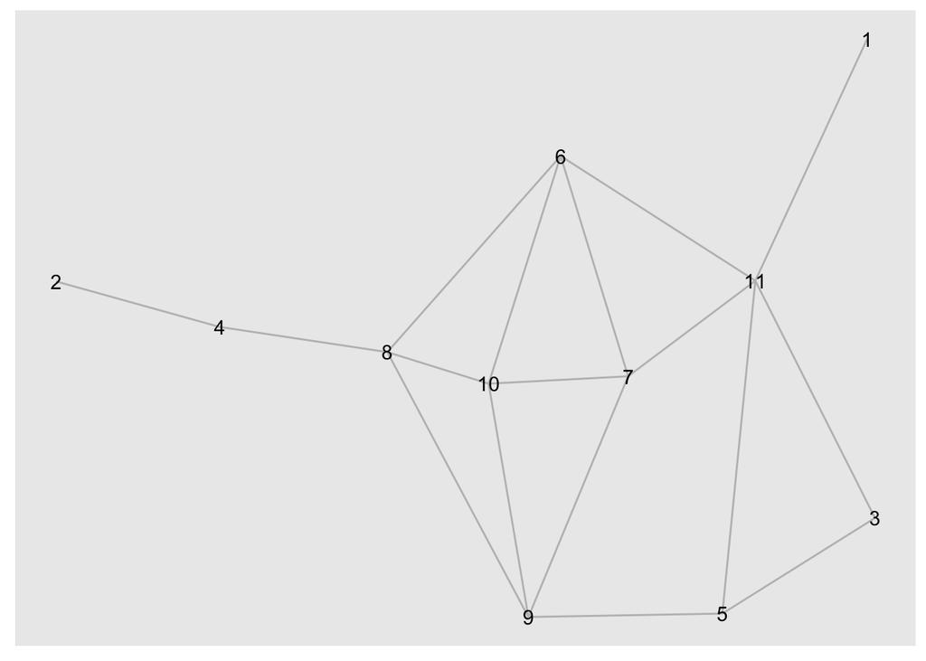

```r
net1_plot
```

Cliques (considers undirected networks with reciprocated ties only, otherwise a clique should be maximal reciprocation)

```r
cliques(net1, min = 3)
```

```
## [[1]]
## + 3/11 vertices, named, from e0b5591:
## [1] 6  8  10
##
## [[2]]
## + 3/11 vertices, named, from e0b5591:
## [1] 8  9  10
##
## [[3]]
## + 3/11 vertices, named, from e0b5591:
## [1] 6  7  10
##
## [[4]]
## + 3/11 vertices, named, from e0b5591:
## [1] 6  7  11
##
## [[5]]
## + 3/11 vertices, named, from e0b5591:
## [1] 7  9  10
##
## [[6]]
## + 3/11 vertices, named, from e0b5591:
## [1] 3  5  11
```

```r
cliques(collab_net, min = 6)
```

```
## [[1]]
## + 6/29 vertices, from c303b09:
## [1]  3 10 19 20 23 27
##
## [[2]]
## + 6/29 vertices, from c303b09:
## [1]  6 10 13 15 20 23
##
## [[3]]
## + 6/29 vertices, from c303b09:
## [1]  3  6  9 19 20 23
##
## [[4]]
## + 6/29 vertices, from c303b09:
## [1]  3  6 10 19 20 23
##
## [[5]]
## + 6/29 vertices, from c303b09:
## [1]  6 10 13 15 16 20
```

- Another way is to partition the network into *factions*, a predetermined number of groups
- It’s more useful to avoid *a priori* definitions
- Bottom-up classification of social/political reality
  - categories are concepts that we analysts (or lay people) apply to single objects by deduction
  - however, they emerge from induction-based inferences by analogy (abstract away from idiosyncratic elements) (Harrison C. White)
  - this is what *community detection* algorithms do: partitioning a graph into dense network regions loosely connected to each other
- Several algorithms can do that: some of them aim to optimize the partition *modularity*, *Q* (i.e., the number of within-group edges compared to a random distribution of the groups)
- The most popular one is the *Girvan-Newman* algorithm (Girvan & Newman, 2002), based on *edge betweenness*, i.e. whether an edge falls along a pair’s geodesics
  1. set the max number of cohesive subsets required, *k*
  2. find the edge with highest edge betweenness
  3. delete it and count the number of components
  4. if the number of components > *k*, stop, otherwise back to 2.
- For directed networks, considers undirected ties (reciprocated ties)

```r
cluster_edge_betweenness(collab_net, directed = FALSE)
```

```
## IGRAPH clustering edge betweenness, groups: 16, mod: 0.058
## + groups:
##   $`1`
##   [1]  1 12
##
##   $`2`
##   [1] 2
##
##   $`3`
##    [1]  3  6  9 10 13 15 16 19 20 23 27
##
##   $`4`
##   + ... omitted several groups/vertices
```

I can retrieve the number of clusters, the node vector in each single cluster as a list item, the modularity

Fast & Greedy: doesn’t search the network so thoroughly, it partitions the network then re-shuffles until it reaches high modularity

```r
cluster_fast_greedy(collab_net)
```

```
## IGRAPH clustering fast greedy, groups: 7, mod: 0.3
## + groups:
##   $`1`
##   [1]  2  4  7  9 14 21
##
##   $`2`
##    [1]  3  8 10 18 19 24 25 26 27 28
##
##   $`3`
##   [1]  6 13 15 16 17 20 22 23
##
##   $`4`
##   + ... omitted several groups/vertices
```

Directed networks: based on random walks

```r
cluster_infomap(support_net)
```

```
## IGRAPH clustering infomap, groups: 7, mod: 0.47
## + groups:
##   $`1`
##   [1]  1  7 21 29
##
##   $`2`
##   [1]  2  4  8  9 14 28
##
##   $`3`
##   [1]  3 18 19 25 26 27
##
##   $`4`
##   + ... omitted several groups/vertices
```

For larger undirected networks, consider Louvain or Leiden

```r
cluster_louvain(collab_net)
```

```
## IGRAPH clustering multi level, groups: 7, mod: 0.3
## + groups:
##   $`1`
##   [1]  1 12
##
##   $`2`
##   [1]  2  4  7  9 14
##
##   $`3`
##    [1]  3  8 10 18 19 21 24 25 26 27 28
##
##   $`4`
##   + ... omitted several groups/vertices
```

plot

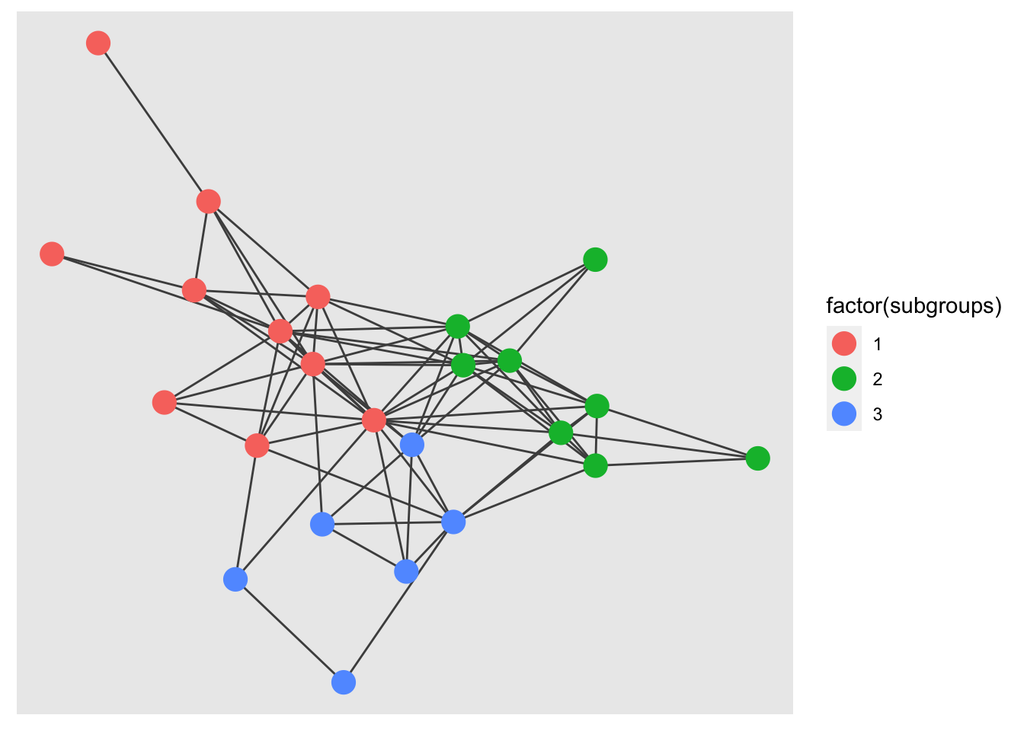

```r
collab_tblgr %>%
  mutate(comp = group_components()) %>%
  filter(comp == 1) %>%
  mutate(subgroups = group_fast_greedy()) %>%
  ggraph(layout = "fr") +
  geom_edge_fan(
    width = .5,
    color = "grey30"
  ) +
  geom_node_point(
    aes(color = factor(subgroups)),
    size = 5
  )
```

Calculating number of *cohesive subgroups* in each ego-network through *Girvan-Newman* algorithm + integrating it into the `egor` object

```r
whole_df[[1]] %<>%
  mutate(
    clusters = graph_list %>%
      map_int(\(egonet) cluster_edge_betweenness(egonet) %>% length)
  )

count(whole_df[[1]], clusters)
```

| clusters | n |
| --- | --- |
| 0 | 3 |
| 1 | 39 |
| 2 | 44 |
| 3 | 56 |
| 4 | 36 |
| 5 | 28 |
| 6 | 10 |
| 7 | 7 |
| 8 | 3 |
| 10 | 2 |

[output cut: 1 more lines]

Testing the hypothetical association between number of cohesive sub-groups and cognitive abilities on the Sociable dataset

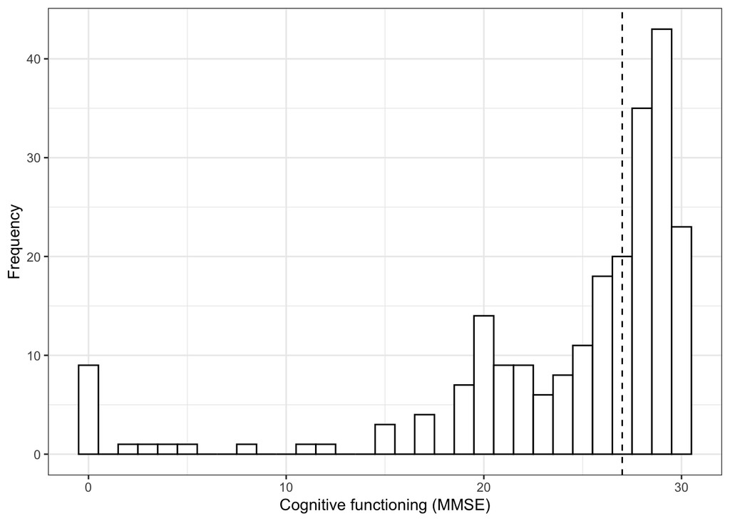

```r
whole_df[[1]] %>%
  ggplot(aes(mmse)) +
#  scale_fill_grey() +
  geom_histogram(binwidth = 1, color = "black", fill = "white") +
  geom_vline(xintercept = median(whole_df[[1]]$mmse, na.rm = T), color = "black", linetype = "dashed") +
  theme_bw() +
  labs(x = "Cognitive functioning (MMSE)", y = "Frequency")
```

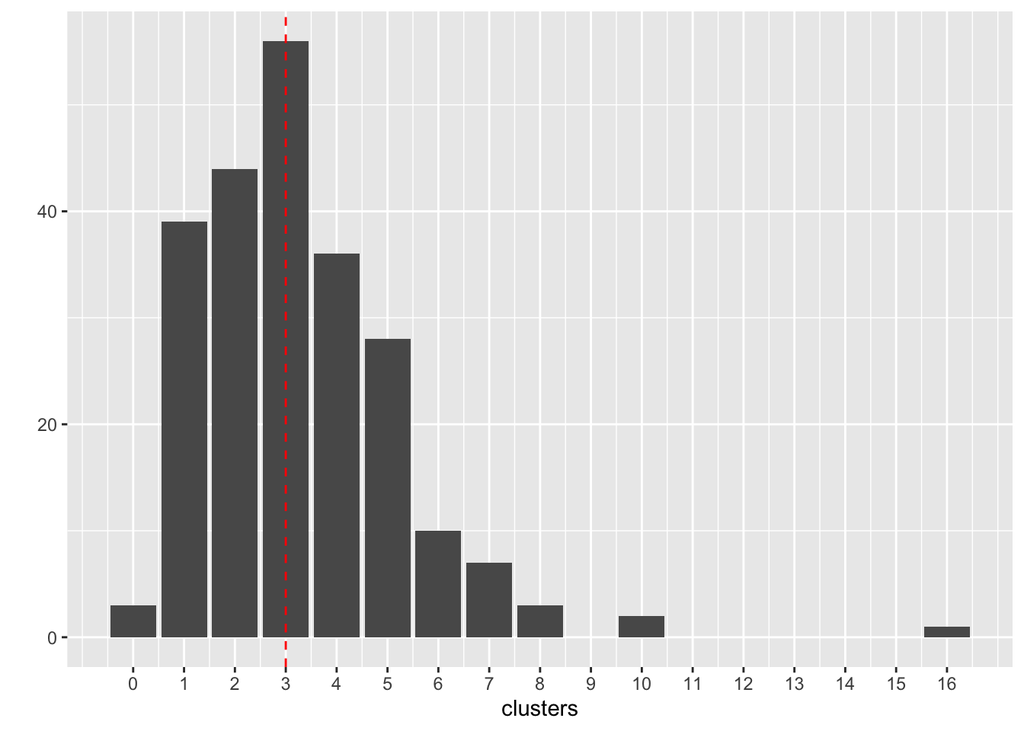

```r
whole_df[[1]] %>%
  ggplot(aes(clusters)) +
  geom_bar() +
  geom_vline(xintercept = median(whole_df[[1]]$clusters, na.rm = TRUE), color = "red", linetype = "dashed") +
  scale_x_continuous(breaks = 0:max(whole_df[[1]]$clusters)) +
  labs(y = "")
```

Association of MMSE with number of cohesive subgroups

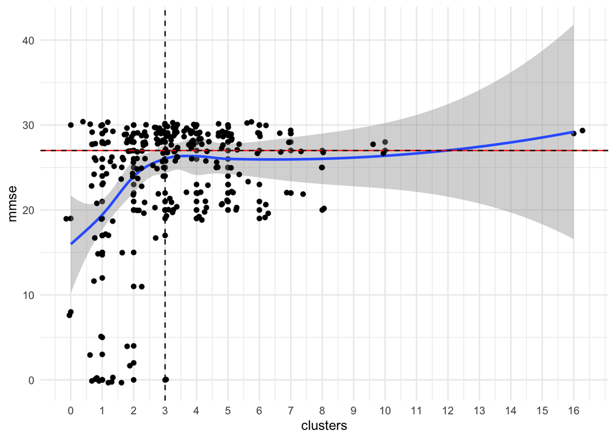

```r
whole_df[[1]] %>%
  ggplot(aes(clusters, mmse)) +
  geom_point() +
  geom_smooth() +
  geom_jitter() +
  scale_x_continuous(breaks = 0:16) +
  geom_hline(yintercept = 27, color = "red") +
  geom_hline(yintercept = median(whole_df[[1]]$mmse, na.rm = T), linetype = "dashed") +
  geom_vline(xintercept = median(whole_df[[1]]$clusters), linetype = "dashed") +
  theme_minimal()
```

```r
m <- mmse ~ clusters + net_size + age + educ + gender
ols <- lm(m, data = whole_df[[1]])
sjPlot::tab_model(ols, vcov.fun = "HC", show.se = TRUE)
```

|  | mmse |  |  |  |
| --- | --- | --- | --- | --- |
| Predictors | Estimates | std. Error | CI | p |
| (Intercept) | 37.01 | 8.02 | 21.21 – 52.80 | **<0.001** |
| clusters | 0.64 | 0.20 | 0.24 – 1.04 | **0.002** |
| net size | 0.11 | 0.07 | -0.03 – 0.25 | 0.116 |
| age | -0.18 | 0.09 | -0.36 – -0.01 | **0.042** |
| educ [middle] | -2.40 | 1.34 | -5.05 – 0.25 | 0.075 |
| educ [primary] | -1.83 | 1.09 | -3.98 – 0.32 | 0.094 |
| educ [uni or higher] | 1.08 | 1.19 | -1.25 – 3.42 | 0.361 |
| gender [Male] | 0.02 | 0.86 | -1.68 – 1.71 | 0.985 |
| Observations | 226 |  |  |  |
| R<sup>2</sup> / R<sup>2</sup> adjusted | 0.145 / 0.117 |  |  |  |

Visualize estimates

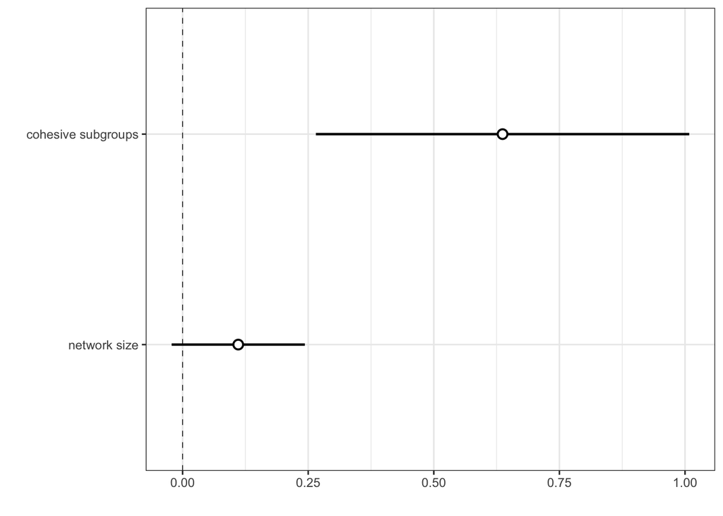

```r
p <- jtools::plot_summs(
  ols,
  coefs = c(
    "cohesive subgroups" = "clusters",
    "network size" = "net_size"
    # ,
    # "age" = "age",
    # "gender: male" = "gendermale",
    # "education: lower secondary" = "education2",
    # "education: higher secondary" = "education3",
    # "education: tertiary" = "education4",
    # "assisted living facility" = "rsa1",
    # "GDS > 1" = "gds.2yes"
  ),
  colors = "black",
  scale = F,
  robust = "HC"
  # ,
  # inner_ci_level = .9
  # ,
  # colors = "rainbow"
)
p +
  theme_bw() +
  labs(x = "", y = "")
```

# 7 Network processes and statistical inference

## 7.1 Reciprocity

We will use a suite of packages including `sna`, `network`, and `ergm` which we’ll use the make statistical inference. We load it here and not at the beginning of the notebook because it can rise conflicts with some `igraph` functions that we have used so far.

Creating a network object, which is needed by functions included in the `sna` and `ergm` packages

```r
(
sup_net <-
  network(
    x = as_adjacency_matrix(support_net),
    node_attributes
  )
)
```

```
##  Network attributes:
##   vertices = 29
##   directed = TRUE
##   hyper = FALSE
##   loops = FALSE
##   multiple = FALSE
##   bipartite = FALSE
##   total edges= 99
##     missing edges= 0
##     non-missing edges= 99
##
##  Vertex attribute names:
##     ...1 age age3 children education family gender id satisfaction seniority seniority_rec soc_capital vertex.names
##
## No edge attributes
```

Inspecting attributes in `network`

```r
sup_net %v% "age"
```

```
##  [1] 40 41 25 28 28 31 39 28 31 28 33 52 31 27 31 31 32 31 34 40 28 31 24 27 31
## [26] 24 34 27 36
```

Let’s calculate the number of complete dyads

```r
mutuality(sup_net) # number of complete dyads (pairs with reciprocal ties)
```

```
## Mut
##  25
```

```r
sna::dyad.census(sup_net) # 812 dyads, 406 pairs of nodes (29 * 28 / 2), 99 dyads with at least one tie, of which 25 are symmetrical, which means 50 ties are in symmetric dyads + 49 which are not in symmetric dyads = 99 dyads with a tie
```

```
##      Mut Asym Null
## [1,]  25   49  332
```

What should we compare it to?

- fix number of nodes
- assume a data-generating process

Let’s compare it with a random graph with 29 nodes. We need to specify a probability for ties to occur. let’s pick random chance

```r
(
rnd_net <-
  rgraph(
    n = 29,
    m = 1,
    tprob = .5
  )
)
```

```
##       [,1] [,2] [,3] [,4] [,5] [,6] [,7] [,8] [,9] [,10] [,11] [,12] [,13]
##  [1,]    0    0    0    1    1    0    0    1    1     0     0     1     0
##  [2,]    1    0    0    0    1    0    0    0    0     1     0     1     0
##  [3,]    0    0    0    0    1    0    1    0    0     0     1     0     0
##  [4,]    1    1    1    0    1    0    0    0    0     1     0     1     1
##  [5,]    1    1    1    1    0    1    0    0    0     1     0     0     1
##  [6,]    1    0    0    1    0    0    0    1    1     0     1     1     1
##  [7,]    1    0    0    1    0    1    0    1    1     1     0     1     1
##  [8,]    0    1    0    1    0    0    1    0    0     0     0     1     0
##  [9,]    1    0    1    1    0    1    0    1    0     0     0     0     0
## [10,]    0    0    0    0    0    1    1    1    1     0     1     0     0
## [11,]    0    0    1    1    1    0    1    0    1     0     0     0     1
## [12,]    0    0    1    0    1    1    1    1    1     1     1     0     1
## [13,]    0    0    0    0    1    1    1    0    1     0     1     0     0
## [14,]    0    1    0    0    1    1    0    1    0     1     0     0     1
```

[output cut: 75 more lines]

```r
sna::dyad.census(rnd_net)
```

```
##      Mut Asym Null
## [1,] 101  202  103
```

**Problem**: 0.5 is clearly unrealistic, so let’s take the density of our empirical network as the baseline probability of ties to occurr

Let’s simulate a whole distribution of random graphs conditioned to *n* = 29 and probability = .12

```r
rnd_net <-
  rgraph(
    n = 29,
    m = 1000,
    tprob = gden(sup_net)
  )
```

Our empirically observed statistic doesn’t even lie within the stochastic distribution!

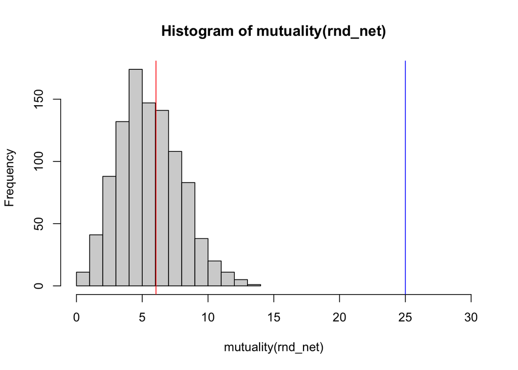

```r
hist(mutuality(rnd_net), xlim = c(0, 30))
abline(v = mean(mutuality(rnd_net)), col="red")
abline(v = mutuality(sup_net), col="blue")
```

What did we do?

- We tested our scientific hypothesis through a binary statistical hypothesis test (reciprocity > than chance?)
- We tested it against a random graph model with the same probability
- This is called *uniform conditional model*: instead of just generating random networks (*U|L*, unrealistic), we generate a uniform distribution of random graphs conditioned on the number of edges
- We conditioned the probability of a tie to a value smaller than random chance
- Two limitations:
  1. we need to assume a more complex form of stochastic dependency: it is not realistic to assume that $P(x_{ij})$ is independent of $P(x_{ji})$?
  - (if $P(x_{ij})$ were independent of $P(x_{ji})$, then $P(x_{ij}) \cap P(x_{ji}) = P(x_{ij}) * P(x_{ji})$)
  - (if not, $P(x_{ij}) \cap P(x_{ji}) = P(x_{ij} | x_{ji}) * P(x_{ji})$)
  2. just a binary hypothesis test, no opportunity for multivariate analysis

# 8 Exponential Random Graph Modelling (ERGM)

(See slides and reading material)

We’ll set a seed to allow for reproducibility

```r
set.seed(123)
```

Let’s start by specifying an ERGM of the support network simply as a function of the likelihood of edges to occur (similar to the role of the intercept in a regression model)

```r
m0 <- sup_net ~ edges
```

All terms that we can specify an ERGM with can be inspected by calling `ergm.terms`.

- We’re now ready to fit the model to the support network data, which is equivalent to computing the likelihood of the data given the model parameters (in this case, only the one parameter weighting the effect of simple ties to be sent by a node to another)
- The software will look for the parameter value that generates a distribution of random graphs with 29 nodes that has 99 as expected number of ties

```r
summary(m0)
```

```
## edges
##    99
```

Then it computes standard errors as uncertainty measures

```r
fit0 <- ergm(m0)
```

```
## Starting maximum pseudolikelihood estimation (MPLE):
```

```
## Evaluating the predictor and response matrix.
```

```
## Maximizing the pseudolikelihood.
```

```
## Finished MPLE.
```

```
## Stopping at the initial estimate.
```

```
## Evaluating log-likelihood at the estimate.
```

Since our model is very simple (no stochastic dependencies), maximum pseudo-likelihood estimation is enough (similar to a logistic regression).

Let’s inspect the fitted model:

```r
summary(fit0)
```

```
## Call:
## ergm(formula = m0)
##
## Maximum Likelihood Results:
##
##       Estimate Std. Error MCMC % z value Pr(>|z|)
## edges  -1.9744     0.1073      0  -18.41   <1e-04 ***
## ---
## Signif. codes:  0 '***' 0.001 '**' 0.01 '*' 0.05 '.' 0.1 ' ' 1
##
##      Null Deviance: 1125.7  on 812  degrees of freedom
##  Residual Deviance:  602.1  on 811  degrees of freedom
##
## AIC: 604.1  BIC: 608.8  (Smaller is better. MC Std. Err. = 0)
```

Estimated parameters can be inspected as follows:

```r
coef(fit0)
```

```
##     edges
## -1.974362
```

The log-odds (natural logarithm of the ratio between a probability and its complement) of a tie to be present in the network (according to our model) is -1.97 * the change-statistic ($\delta$) in the number of ties, which is equal to 1 in this case, as every tie addition increases the statistic of the `edges` term by 1

```r
coef(fit0) * 1
```

```
##     edges
## -1.974362
```

To compute $P(x_{ij})$, we calculate the inverse of the logit

```r
exp(coef(fit0)) / (1 + exp(coef(fit0))) * 1
```

```
##     edges
## 0.1219212
```

Same as the density! In fact, the model we estimated is equivalent to the simple *U|L* model shown above.

- Let’s now complicate the model by assuming a form of stochastic dependency in our data
- We assume that $x_{ij}$ is stochastically dependent on $x_{ji}$

We do this by specifying the model with a further term which calculates the number of complete dyads in the data

```r
m1 <- update.formula(m0, . ~ . + mutual)
summary(m1)
```

```
##  edges mutual
##     99     25
```

Fitting the model to the data

```r
fit1 <- ergm(m1)
```

```
## Starting maximum pseudolikelihood estimation (MPLE):
```

```
## Evaluating the predictor and response matrix.
```

```
## Maximizing the pseudolikelihood.
```

```
## Finished MPLE.
```

```
## Starting Monte Carlo maximum likelihood estimation (MCMLE):
```

```
## Iteration 1 of at most 60:
```

```
## Optimizing with step length 1.0000.
```

```
## The log-likelihood improved by 0.0233.
```

[output not shown]

MPLE not enough now, because of dependency of observations: we need to simulate a stochastic network formation process via *Markov Chain Monte Carlo* to be able to compute *Maximum Likelihood* estimates (see slides and reading)

```r
summary(fit1)
```

```
## Call:
## ergm(formula = m1)
##
## Monte Carlo Maximum Likelihood Results:
##
##        Estimate Std. Error MCMC % z value Pr(>|z|)
## edges   -2.6076     0.1542      0 -16.913   <1e-04 ***
## mutual   2.6480     0.3425      0   7.731   <1e-04 ***
## ---
## Signif. codes:  0 '***' 0.001 '**' 0.01 '*' 0.05 '.' 0.1 ' ' 1
##
##      Null Deviance: 1125.7  on 812  degrees of freedom
##  Residual Deviance:  548.1  on 810  degrees of freedom
##
## AIC: 552.1  BIC: 561.5  (Smaller is better. MC Std. Err. = 0.7841)
```

- The estimate of the reciprocity parameter (`mutual`) is positive and its standard error is small enough to be able to claim strong evidence of a reciprocation process in explaining our observed the network
- There are more complete dyads in our network than in random graphs with 29 nodes and .12 density, given that reciprocal ties are stochastically dependent.
- We can make things even more complex, to disentangle the confounding effect of transitive closure.
- We do this by specifying the `gwesp` effect (*Geometrically Weighted Edgewise Shared Partners*), which counts the number of transitive triplets and estimate its marginally decreasing effect by a `decay` parameter.

```r
m2 <- update.formula(m1, . ~ . + gwesp(decay = .5, fixed = T))
```

- This can be hard to fit. In case the estimates do not converge, we need to assume further forms of stochastic dependency, so the MCMC engine has enough information to be able to generate the random graph distribution.
- A solution can be to specify a `twopath` term, which counts the number of paths of size 2 as evidence of open triads.

```r
m3 <- update.formula(m2, . ~ . + twopath)
fit3 <- ergm(m3)
```

```
## Starting maximum pseudolikelihood estimation (MPLE):
```

```
## Evaluating the predictor and response matrix.
```

```
## Maximizing the pseudolikelihood.
```

```
## Finished MPLE.
```

```
## Starting Monte Carlo maximum likelihood estimation (MCMLE):
```

```
## Iteration 1 of at most 60:
```

```
## Optimizing with step length 1.0000.
```

```
## The log-likelihood improved by 0.9883.
```

```
## Estimating equations are not within tolerance region.
```

```
## Iteration 2 of at most 60:
```

```
## Optimizing with step length 1.0000.
```

```
## The log-likelihood improved by 0.0520.
```

[output not shown]

```r
summary(fit3)
```

```
## Call:
## ergm(formula = m3)
##
## Monte Carlo Maximum Likelihood Results:
##
##                 Estimate Std. Error MCMC % z value Pr(>|z|)
## edges           -2.25234    0.35384      0  -6.365   <1e-04 ***
## mutual           1.98174    0.35145      0   5.639   <1e-04 ***
## gwesp.fixed.0.5  1.07622    0.16372      0   6.574   <1e-04 ***
## twopath         -0.24153    0.05689      0  -4.245   <1e-04 ***
## ---
## Signif. codes:  0 '***' 0.001 '**' 0.01 '*' 0.05 '.' 0.1 ' ' 1
##
##      Null Deviance: 1125.7  on 812  degrees of freedom
##  Residual Deviance:  493.5  on 808  degrees of freedom
##
## AIC: 501.5  BIC: 520.3  (Smaller is better. MC Std. Err. = 0.8871)
```

We still have strong evidence of reciprocity, even by controlling by transitive closure.

We might want to control for the effect of age, as a *social selection* process based on node attributes

```r
m4 <- update.formula(m3, . ~ . + nodeicov("age") + nodeocov("age") + nodematch("age"))
fit4 <- ergm(m4)
```

```
## Starting maximum pseudolikelihood estimation (MPLE):
```

```
## Evaluating the predictor and response matrix.
```

```
## Maximizing the pseudolikelihood.
```

```
## Finished MPLE.
```

```
## Starting Monte Carlo maximum likelihood estimation (MCMLE):
```

```
## Iteration 1 of at most 60:
```

```
## Optimizing with step length 1.0000.
```

```
## The log-likelihood improved by 1.2442.
```

```
## Estimating equations are not within tolerance region.
```

```
## Iteration 2 of at most 60:
```

```
## Optimizing with step length 1.0000.
```

```
## The log-likelihood improved by 0.0580.
```

[output not shown]

```r
summary(fit4)
```

```
## Call:
## ergm(formula = m4)
##
## Monte Carlo Maximum Likelihood Results:
##
##                 Estimate Std. Error MCMC % z value Pr(>|z|)
## edges           -3.00414    0.79149      0  -3.796 0.000147 ***
## mutual           2.08797    0.35956      0   5.807  < 1e-04 ***
## gwesp.fixed.0.5  1.03909    0.16469      0   6.309  < 1e-04 ***
## twopath         -0.23517    0.05704      0  -4.123  < 1e-04 ***
## nodeicov.age     0.03261    0.01615      0   2.020 0.043424 *
## nodeocov.age    -0.01266    0.01890      0  -0.670 0.502804
## nodematch.age    0.52107    0.20087      0   2.594 0.009485 **
## ---
## Signif. codes:  0 '***' 0.001 '**' 0.01 '*' 0.05 '.' 0.1 ' ' 1
##
##      Null Deviance: 1125.7  on 812  degrees of freedom
##  Residual Deviance:  484.3  on 805  degrees of freedom
##
## AIC: 498.3  BIC: 531.2  (Smaller is better. MC Std. Err. = 0.5778)
```

Still strong evidence of reciprocity, even controlling by the confounding effects of transitive closure and age-based selection.